# Effect of Covid on the Price of several Species

#### 2.7.2.1 Price vs Abundance (scatter plot)

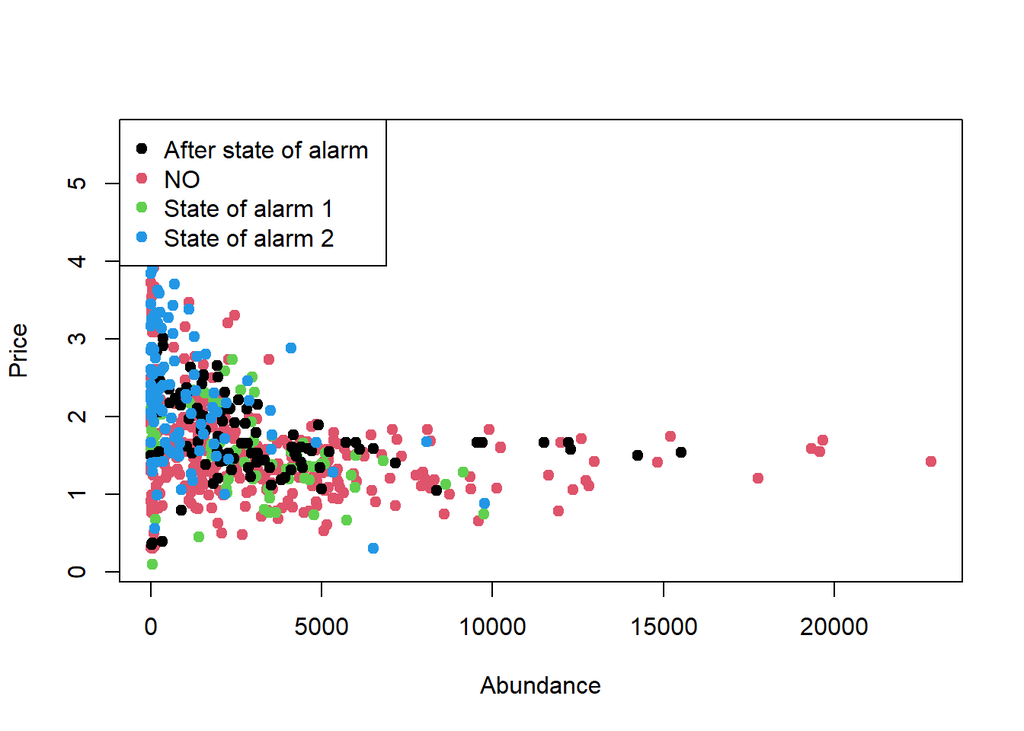

```r
plot(data1$kgs,data1$euros,
     pch = 19,
     col = factor(data1$Covid),xlab="Abundance",ylab = "Price")

# Legend
legend("topleft",
       legend = levels(factor(data1$Covid)),
       pch = 19,
       col = factor(levels(factor(data1$Covid))))
```

```r
cor.test(data1$kgs,data1$euros)
```

```
##
##  Pearson's product-moment correlation
##
## data:  data1$kgs and data1$euros
## t = -8.5009, df = 586, p-value < 2.2e-16
## alternative hypothesis: true correlation is not equal to 0
## 95 percent confidence interval:
##  -0.4014350 -0.2573696
## sample estimates:
##        cor
## -0.3313322
```

Is gamma a correct distribution for the response variable PRICE?

```r
summary(data1$euros)
```

```
##    Min. 1st Qu.  Median    Mean 3rd Qu.    Max.
##  0.1001  1.2638  1.5868  1.7622  2.1001  5.6000
```

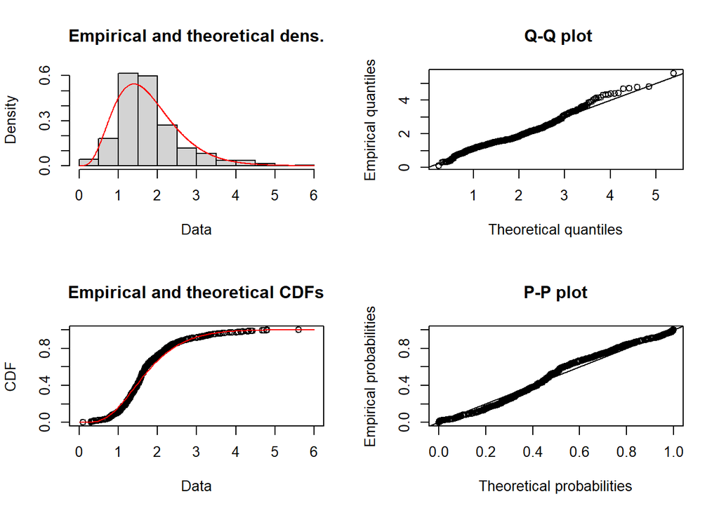

```r
a=fitdist(data1$euros, distr = "gamma",start=list(shape = 1, rate = 2), lower = -1,method = "mme")
plot(a)
```

```r
ks.test(na.omit(data1$euros), "pgamma", a$estimate[1],a$estimate[2])
```

```
##
##  One-sample Kolmogorov-Smirnov test
##
## data:  na.omit(data1$euros)
## D = 0.070174, p-value = 0.00611
## alternative hypothesis: two-sided
```

```r
gamma_test(data1$euros)
```

```
##
##  Test of fit for the Gamma distribution
##
## data:  data1$euros
## V = 3.3584, p-value = 0.01756
```

Is gamma a correct distribution for the response variable ABUNDANCE?

```r
summary(data1$kgs)
```

```
##     Min.  1st Qu.   Median     Mean  3rd Qu.     Max.
##     2.45   550.93  1963.55  2862.07  4114.44 22825.62
```

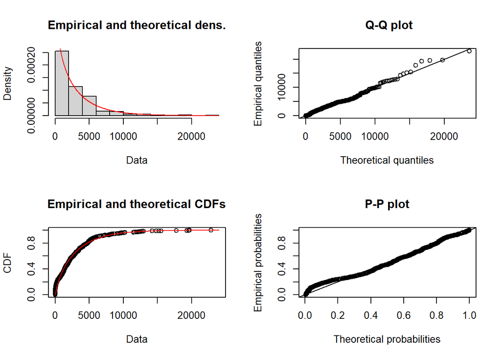

```r
a=fitdist(data1$kgs, distr = "gamma",start=list(shape = 1, rate = 2), lower = -1,method = "mme")
plot(a)
```

```r
ks.test(na.omit(data1$kgs), "pgamma", a$estimate[1],a$estimate[2])
```

```
##
##  One-sample Kolmogorov-Smirnov test
##
## data:  na.omit(data1$kgs)
## D = 0.079392, p-value = 0.001207
## alternative hypothesis: two-sided
```

```r
gamma_test(data1$kgs)
```

```
##
##  Test of fit for the Gamma distribution
##
## data:  data1$kgs
## V = -2.8252, p-value = 0.04575
```

### 2.7.3 Regression model

```r
x=as.factor(data1$Covid)
table(x)
```

```
## x
## After state of alarm                     NO      State of alarm 1
##                    96                   320                    71
##      State of alarm 2
##                   101
```

```r
y=as.numeric(data1$euros)
x=relevel(x, ref = "NO")
z=data1$kgs


Model<-glm((y)~x,family=Gamma(link=log))
cooksd <- cooks.distance(Model)
influential <- cooksd[(cooksd > (3 * mean(cooksd, na.rm = TRUE)))]
influential=as.numeric(names(influential))
y=y[-influential]
xaux=x[-influential]
Model<-glm((y)~xaux,family=Gamma(link=log))
summary(Model)
```

```
##
## Call:
## glm(formula = (y) ~ xaux, family = Gamma(link = log))
##
## Deviance Residuals:
##     Min       1Q   Median       3Q      Max
## -1.2506  -0.2269  -0.0355   0.1659   0.8788
##
## Coefficients:
##                           Estimate Std. Error t value Pr(>|t|)
## (Intercept)                0.39761    0.01808  21.991  < 2e-16 ***
## xauxAfter state of alarm   0.15093    0.03806   3.965 8.35e-05 ***
## xauxState of alarm 1       0.02409    0.04642   0.519    0.604
## xauxState of alarm 2       0.42869    0.03858  11.112  < 2e-16 ***
## ---
## Signif. codes:  0 '***' 0.001 '**' 0.01 '*' 0.05 '.' 0.1 ' ' 1
##
## (Dispersion parameter for Gamma family taken to be 0.09872528)
##
##     Null deviance: 68.863  on 528  degrees of freedom
## Residual deviance: 55.174  on 525  degrees of freedom
## AIC: 792.16
##
## Number of Fisher Scoring iterations: 4
```

```r
Model.aux<-glm((z)~x,family=Gamma(link=log))

cooksd <- cooks.distance(Model.aux)
influential <- cooksd[(cooksd > (3 * mean(cooksd, na.rm = TRUE)))]
influential=as.numeric(names(influential))
z=z[-influential]
xaux=x[-influential]
Model.aux<-glm((z)~xaux,family=Gamma(link=log))
summary(Model.aux)
```

```
##
## Call:
## glm(formula = (z) ~ xaux, family = Gamma(link = log))
##
## Deviance Residuals:
##     Min       1Q   Median       3Q      Max
## -3.4231  -1.0195  -0.2192   0.4721   1.9585
##
## Coefficients:
##                           Estimate Std. Error t value Pr(>|t|)
## (Intercept)                7.93941    0.05108 155.421   <2e-16 ***
## xauxAfter state of alarm  -0.12186    0.10850  -1.123    0.262
## xauxState of alarm 1      -0.03088    0.12028  -0.257    0.797
## xauxState of alarm 2      -1.46342    0.10710 -13.664   <2e-16 ***
## ---
## Signif. codes:  0 '***' 0.001 '**' 0.01 '*' 0.05 '.' 0.1 ' ' 1
##
## (Dispersion parameter for Gamma family taken to be 0.8063329)
##
##     Null deviance: 1003.37  on 555  degrees of freedom
## Residual deviance:  889.05  on 552  degrees of freedom
## AIC: 9636.1
##
## Number of Fisher Scoring iterations: 6
```

## 2.8 Argyrosomus regius

```r
data1=subset(data_A,data_A$specie=="MGR-CORVINA")
```

### 2.8.1 Exploratory analysis

#### 2.8.1.1 Price by covid category (boxplot)

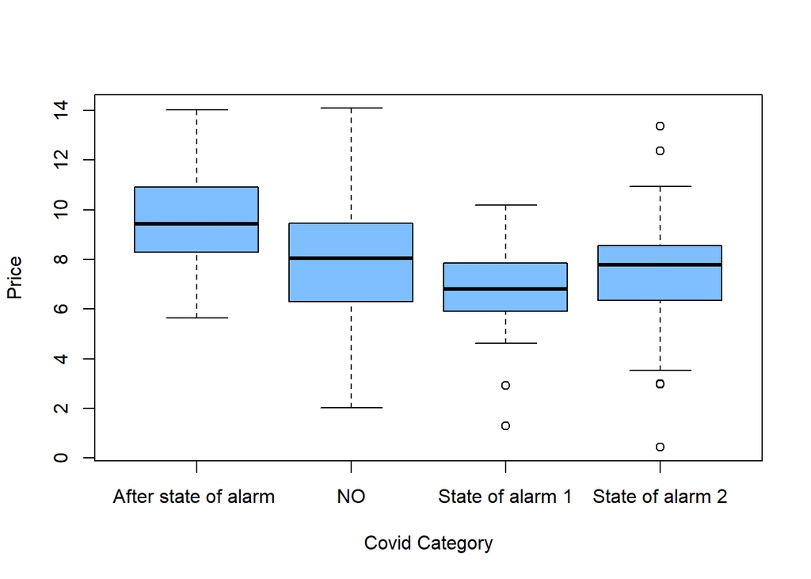

```r
boxplot(data1$euros~data1$Covid, col = rgb(0, 0.5, 1, alpha = 0.5),xlab="Covid Category",ylab="Price")
```

### 2.8.2 Abundance by covid category (boxplot)

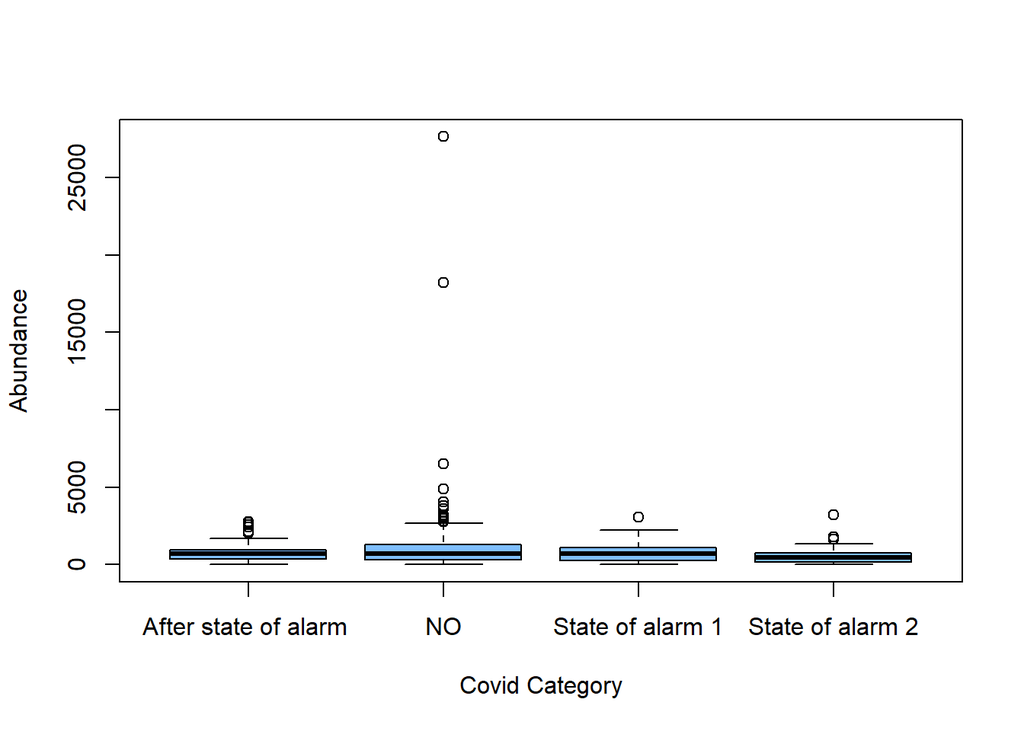

```r
boxplot(data1$kgs~data1$Covid, col = rgb(0, 0.5, 1, alpha = 0.5),xlab="Covid Category",ylab="Abundance")
```

#### 2.8.2.1 Price vs Abundance (scatter plot)

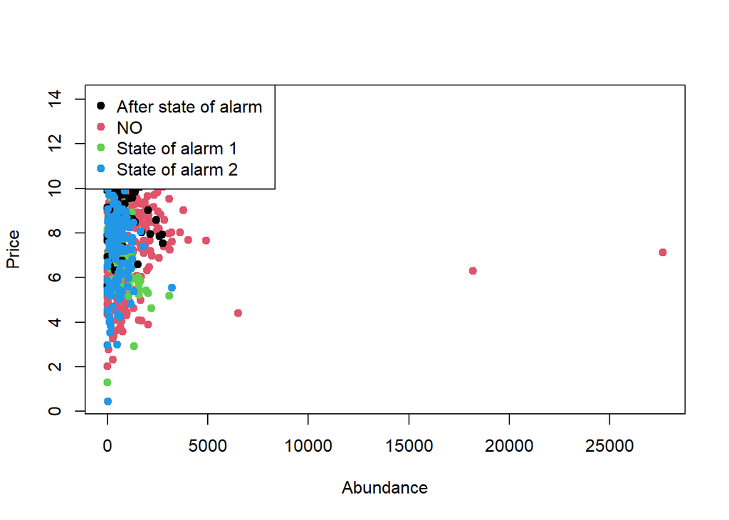

```r
plot(data1$kgs,data1$euros,
     pch = 19,
     col = factor(data1$Covid),xlab="Abundance",ylab = "Price")

# Legend
legend("topleft",
       legend = levels(factor(data1$Covid)),
       pch = 19,
       col = factor(levels(factor(data1$Covid))))
```

```r
cor.test(data1$kgs,data1$euros)
```

```
##
##  Pearson's product-moment correlation
##
## data:  data1$kgs and data1$euros
## t = -1.0849, df = 665, p-value = 0.2783
## alternative hypothesis: true correlation is not equal to 0
## 95 percent confidence interval:
##  -0.11757465  0.03398864
## sample estimates:
##         cor
## -0.04203483
```

Is gamma a correct distribution for the response variable PRICE?

```r
summary(data1$euros)
```

```
##    Min. 1st Qu.  Median    Mean 3rd Qu.    Max.
##   0.440   6.471   8.016   7.953   9.312  14.091
```

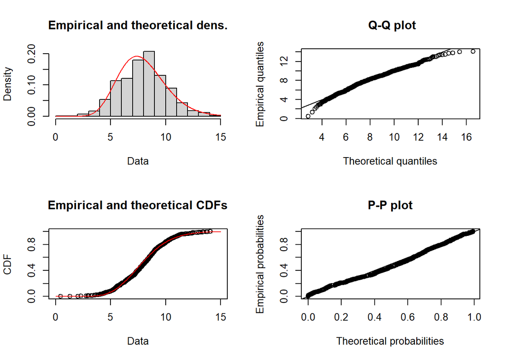

```r
a=fitdist(data1$euros, distr = "gamma",start=list(shape = 1, rate = 2), lower = -1,method = "mme")
plot(a)
```

```r
ks.test(na.omit(data1$euros), "pgamma", a$estimate[1],a$estimate[2])
```

```
##
##  One-sample Kolmogorov-Smirnov test
##
## data:  na.omit(data1$euros)
## D = 0.054589, p-value = 0.03755
## alternative hypothesis: two-sided
```

```r
gamma_test(data1$euros)
```

```
##
##  Test of fit for the Gamma distribution
##
## data:  data1$euros
## V = -9.5293, p-value = 1.603e-11
```

Is gamma a correct distribution for the response variable ABUNDANCE?

```r
summary(data1$kgs)
```

```
##     Min.  1st Qu.   Median     Mean  3rd Qu.     Max.
##     0.96   267.83   612.00   841.90  1031.45 27639.82
```

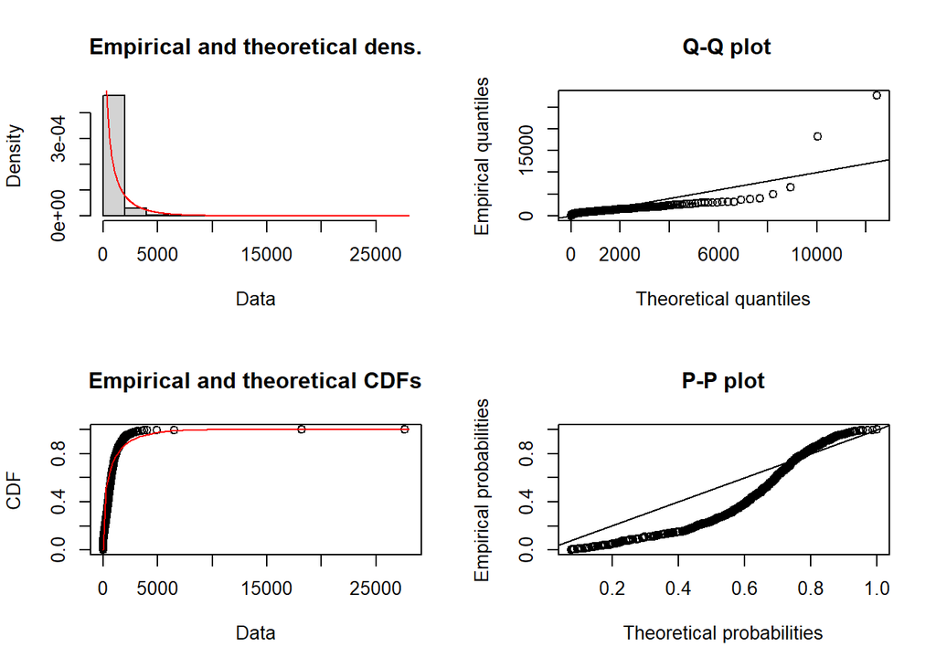

```r
a=fitdist(data1$kgs, distr = "gamma",start=list(shape = 1, rate = 2), lower = -1,method = "mme")
plot(a)
```

```r
ks.test(na.omit(data1$kgs), "pgamma", a$estimate[1],a$estimate[2])
```

```
##
##  One-sample Kolmogorov-Smirnov test
##
## data:  na.omit(data1$kgs)
## D = 0.26748, p-value < 2.2e-16
## alternative hypothesis: two-sided
```

```r
gamma_test(data1$kgs)
```

```
##
##  Test of fit for the Gamma distribution
##
## data:  data1$kgs
## V = 30.862, p-value < 2.2e-16
```

### 2.8.3 Regression model

```r
x=as.factor(data1$Covid)
table(x)
```

```
## x
## After state of alarm                     NO      State of alarm 1
##                    99                   338                    77
##      State of alarm 2
##                   153
```

```r
y=as.numeric(data1$euros)
x=relevel(x, ref = "NO")
z=data1$kgs


Model<-glm((y)~x,family=Gamma(link=log))
cooksd <- cooks.distance(Model)
influential <- cooksd[(cooksd > (3 * mean(cooksd, na.rm = TRUE)))]
influential=as.numeric(names(influential))
y=y[-influential]
xaux=x[-influential]
Model<-glm((y)~xaux,family=Gamma(link=log))
summary(Model)
```

```
##
## Call:
## glm(formula = (y) ~ xaux, family = Gamma(link = log))
##
## Deviance Residuals:
##      Min        1Q    Median        3Q       Max
## -0.74411  -0.16433   0.01151   0.14471   0.49759
##
## Coefficients:
##                           Estimate Std. Error t value Pr(>|t|)
## (Intercept)                2.06332    0.01213 170.074  < 2e-16 ***
## xauxAfter state of alarm   0.18844    0.02626   7.176 2.09e-12 ***
## xauxState of alarm 1      -0.15545    0.02983  -5.211 2.57e-07 ***
## xauxState of alarm 2      -0.03338    0.02253  -1.482    0.139
## ---
## Signif. codes:  0 '***' 0.001 '**' 0.01 '*' 0.05 '.' 0.1 ' ' 1
##
## (Dispersion parameter for Gamma family taken to be 0.04827615)
##
##     Null deviance: 37.400  on 615  degrees of freedom
## Residual deviance: 32.427  on 612  degrees of freedom
## AIC: 2463.9
##
## Number of Fisher Scoring iterations: 4
```

```r
Model.aux<-glm((z)~x,family=Gamma(link=log))

cooksd <- cooks.distance(Model.aux)
influential <- cooksd[(cooksd > (3 * mean(cooksd, na.rm = TRUE)))]
influential=as.numeric(names(influential))
z=z[-influential]
xaux=x[-influential]
Model.aux<-glm((z)~xaux,family=Gamma(link=log))
summary(Model.aux)
```

```
##
## Call:
## glm(formula = (z) ~ xaux, family = Gamma(link = log))
##
## Deviance Residuals:
##     Min       1Q   Median       3Q      Max
## -3.4067  -0.8739  -0.1511   0.4126   1.9495
##
## Coefficients:
##                           Estimate Std. Error t value Pr(>|t|)
## (Intercept)                6.76089    0.04383 154.255  < 2e-16 ***
## xauxAfter state of alarm  -0.29403    0.09381  -3.134   0.0018 **
## xauxState of alarm 1      -0.25958    0.10336  -2.511   0.0123 *
## xauxState of alarm 2      -0.56362    0.07865  -7.166 2.11e-12 ***
## ---
## Signif. codes:  0 '***' 0.001 '**' 0.01 '*' 0.05 '.' 0.1 ' ' 1
##
## (Dispersion parameter for Gamma family taken to be 0.6396955)
##
##     Null deviance: 782.02  on 648  degrees of freedom
## Residual deviance: 749.44  on 645  degrees of freedom
## AIC: 9830.3
##
## Number of Fisher Scoring iterations: 6
```

## 2.9 Pagellus bogaraveo

```r
data1=subset(data_A,data_A$specie=="SBR-BESUGO DE LA PINTA O VORAZ")
```

### 2.9.1 Exploratory analysis

#### 2.9.1.1 Price by covid category (boxplot)

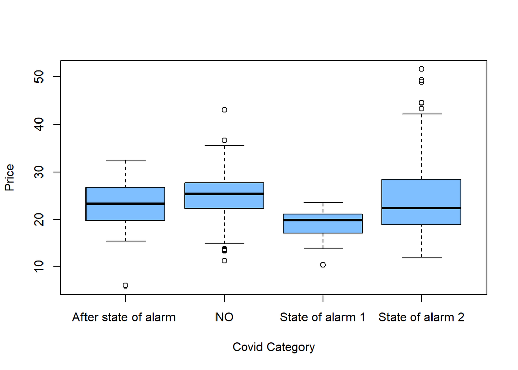

```r
boxplot(data1$euros~data1$Covid, col = rgb(0, 0.5, 1, alpha = 0.5),xlab="Covid Category",ylab="Price")
```

### 2.9.2 Abundance by covid category (boxplot)

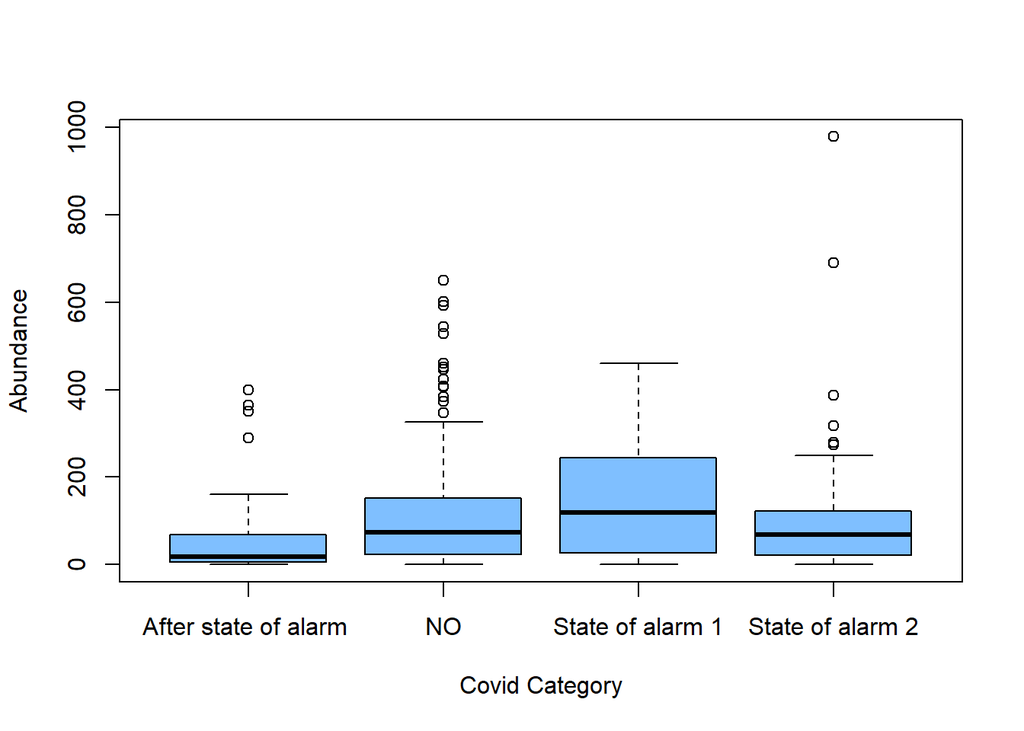

```r
boxplot(data1$kgs~data1$Covid, col = rgb(0, 0.5, 1, alpha = 0.5),xlab="Covid Category",ylab="Abundance")
```

#### 2.9.2.1 Price vs Abundance (scatter plot)

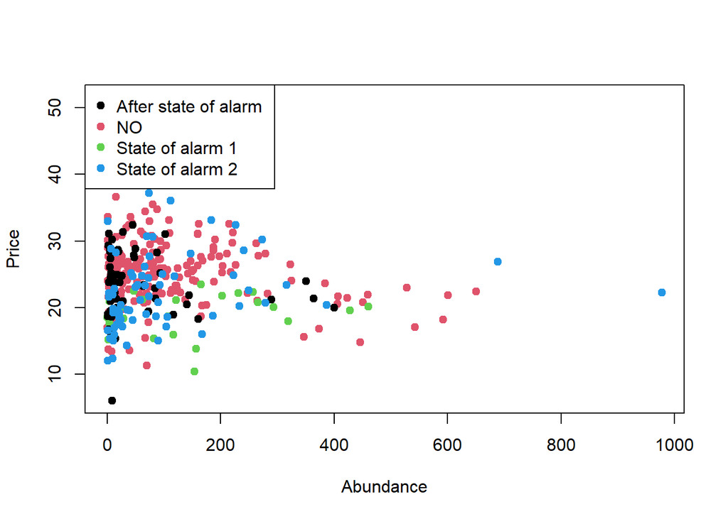

```r
plot(data1$kgs,data1$euros,
     pch = 19,
     col = factor(data1$Covid),xlab="Abundance",ylab = "Price")

# Legend
legend("topleft",
       legend = levels(factor(data1$Covid)),
       pch = 19,
       col = factor(levels(factor(data1$Covid))))
```

```r
cor.test(data1$kgs,data1$euros)
```

```
##
##  Pearson's product-moment correlation
##
## data:  data1$kgs and data1$euros
## t = -0.51511, df = 341, p-value = 0.6068
## alternative hypothesis: true correlation is not equal to 0
## 95 percent confidence interval:
##  -0.13338572  0.07824236
## sample estimates:
##         cor
## -0.02788412
```

Is gamma a correct distribution for the response variable PRICE?

```r
summary(data1$euros)
```

```
##    Min. 1st Qu.  Median    Mean 3rd Qu.    Max.
##   5.992  20.743  24.017  24.424  27.487  51.611
```

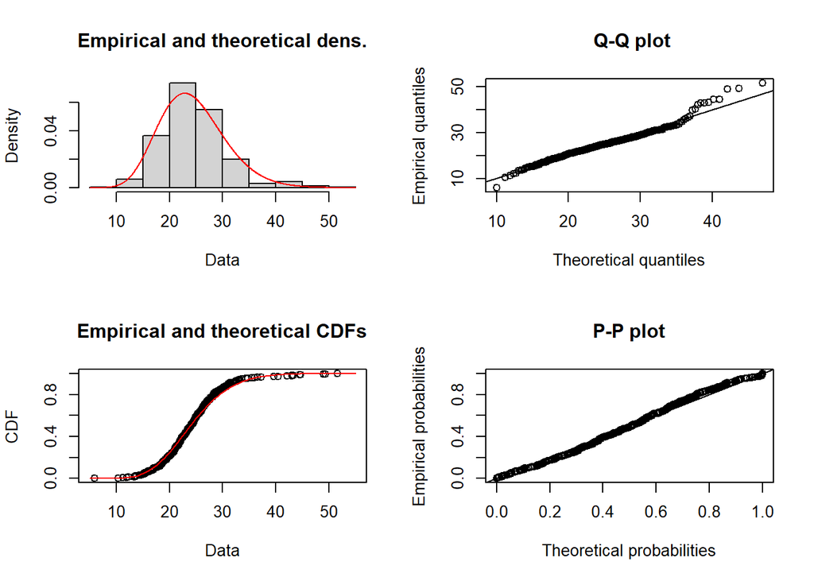

```r
a=fitdist(data1$euros, distr = "gamma",start=list(shape = 1, rate = 2), lower = -1,method = "mme")
plot(a)
```

```r
ks.test(na.omit(data1$euros), "pgamma", a$estimate[1],a$estimate[2])
```

```
##
##  One-sample Kolmogorov-Smirnov test
##
## data:  na.omit(data1$euros)
## D = 0.052483, p-value = 0.3012
## alternative hypothesis: two-sided
```

```r
gamma_test(data1$euros)
```

```
##
##  Test of fit for the Gamma distribution
##
## data:  data1$euros
## V = 1.9694, p-value = 0.1637
```

Is gamma a correct distribution for the response variable ABUNDANCE?

```r
summary(data1$kgs)
```

```
##    Min. 1st Qu.  Median    Mean 3rd Qu.    Max.
##    0.30   17.63   65.40  105.00  142.16  977.94
```

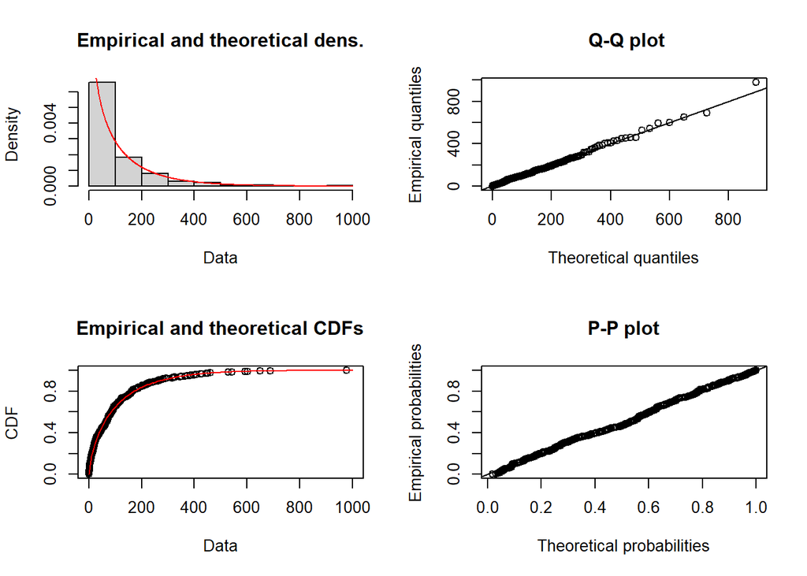

```r
a=fitdist(data1$kgs, distr = "gamma",start=list(shape = 1, rate = 2), lower = -1,method = "mme")
plot(a)
```

```r
ks.test(na.omit(data1$kgs), "pgamma", a$estimate[1],a$estimate[2])
```

```
##
##  One-sample Kolmogorov-Smirnov test
##
## data:  na.omit(data1$kgs)
## D = 0.037043, p-value = 0.7343
## alternative hypothesis: two-sided
```

```r
gamma_test(data1$kgs)
```

```
##
##  Test of fit for the Gamma distribution
##
## data:  data1$kgs
## V = 1.0456, p-value = 0.4597
```

### 2.9.3 Regression model

```r
x=as.factor(data1$Covid)
table(x)
```

```
## x
## After state of alarm                     NO      State of alarm 1
##                    55                   188                    24
##      State of alarm 2
##                    76
```

```r
y=as.numeric(data1$euros)
x=relevel(x, ref = "NO")
z=data1$kgs


Model<-glm((y)~x,family=Gamma(link=log))
cooksd <- cooks.distance(Model)
influential <- cooksd[(cooksd > (3 * mean(cooksd, na.rm = TRUE)))]
influential=as.numeric(names(influential))
y=y[-influential]
xaux=x[-influential]
Model<-glm((y)~xaux,family=Gamma(link=log))
summary(Model)
```

```
##
## Call:
## glm(formula = (y) ~ xaux, family = Gamma(link = log))
##
## Deviance Residuals:
##      Min        1Q    Median        3Q       Max
## -0.70475  -0.12755   0.00423   0.10140   0.42584
##
## Coefficients:
##                           Estimate Std. Error t value Pr(>|t|)
## (Intercept)                3.22304    0.01326 243.005  < 2e-16 ***
## xauxAfter state of alarm  -0.09838    0.02882  -3.414 0.000723 ***
## xauxState of alarm 1      -0.25922    0.04164  -6.225 1.54e-09 ***
## xauxState of alarm 2      -0.11906    0.02653  -4.488 1.01e-05 ***
## ---
## Signif. codes:  0 '***' 0.001 '**' 0.01 '*' 0.05 '.' 0.1 ' ' 1
##
## (Dispersion parameter for Gamma family taken to be 0.03272011)
##
##     Null deviance: 12.566  on 318  degrees of freedom
## Residual deviance: 10.833  on 315  degrees of freedom
## AIC: 1848
##
## Number of Fisher Scoring iterations: 4
```

```r
Model.aux<-glm((z)~x,family=Gamma(link=log))

cooksd <- cooks.distance(Model.aux)
influential <- cooksd[(cooksd > (3 * mean(cooksd, na.rm = TRUE)))]
influential=as.numeric(names(influential))
z=z[-influential]
xaux=x[-influential]
Model.aux<-glm((z)~xaux,family=Gamma(link=log))
summary(Model.aux)
```

```
##
## Call:
## glm(formula = (z) ~ xaux, family = Gamma(link = log))
##
## Deviance Residuals:
##     Min       1Q   Median       3Q      Max
## -3.1012  -1.2514  -0.3302   0.3788   2.0429
##
## Coefficients:
##                           Estimate Std. Error t value Pr(>|t|)
## (Intercept)                4.60158    0.07574  60.757  < 2e-16 ***
## xauxAfter state of alarm  -1.11609    0.16349  -6.826 4.32e-11 ***
## xauxState of alarm 1       0.10783    0.23606   0.457    0.648
## xauxState of alarm 2      -0.17975    0.14183  -1.267    0.206
## ---
## Signif. codes:  0 '***' 0.001 '**' 0.01 '*' 0.05 '.' 0.1 ' ' 1
##
## (Dispersion parameter for Gamma family taken to be 1.049716)
##
##     Null deviance: 497.21  on 326  degrees of freedom
## Residual deviance: 456.65  on 323  degrees of freedom
## AIC: 3539.2
##
## Number of Fisher Scoring iterations: 6
```

## 2.10 Scomber japonicus

```r
data1=subset(data_A,data_A$specie=="MAS-CABALLA DEL SUR O TONINO")
head(data1)
```

```
##      Covid       date                       specie    euros   kgs
## 3675    NO 23/08/2019 MAS-CABALLA DEL SUR O TONINO 1.657784 35.65
## 3784    NO 30/08/2019 MAS-CABALLA DEL SUR O TONINO 1.446735 14.55
## 4890    NO 13/11/2019 MAS-CABALLA DEL SUR O TONINO 1.101961  2.55
## 4907    NO 14/11/2019 MAS-CABALLA DEL SUR O TONINO 2.100901  5.55
## 4925    NO 15/11/2019 MAS-CABALLA DEL SUR O TONINO 1.700000  7.40
## 5101    NO 29/11/2019 MAS-CABALLA DEL SUR O TONINO 2.000000  2.75
```

# 3 Mediterranean

## 3.1 Trachurus mediterraneus

```r
data1=subset(data_M,data_M$specie=="HMM-JUREL BLANCO")
```

### 3.1.1 Exploratory analysis

#### 3.1.1.1 Price by covid category (boxplot)

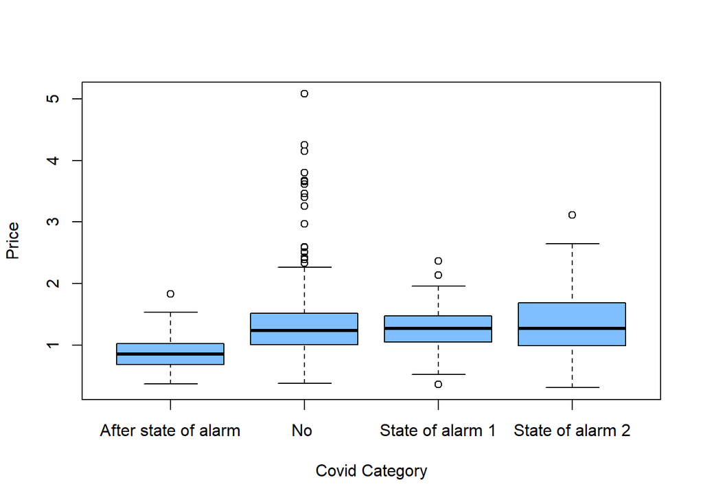

```r
boxplot(data1$euros~data1$Covid, col = rgb(0, 0.5, 1, alpha = 0.5),xlab="Covid Category",ylab="Price")
```

### 3.1.2 Abundance by covid category (boxplot)

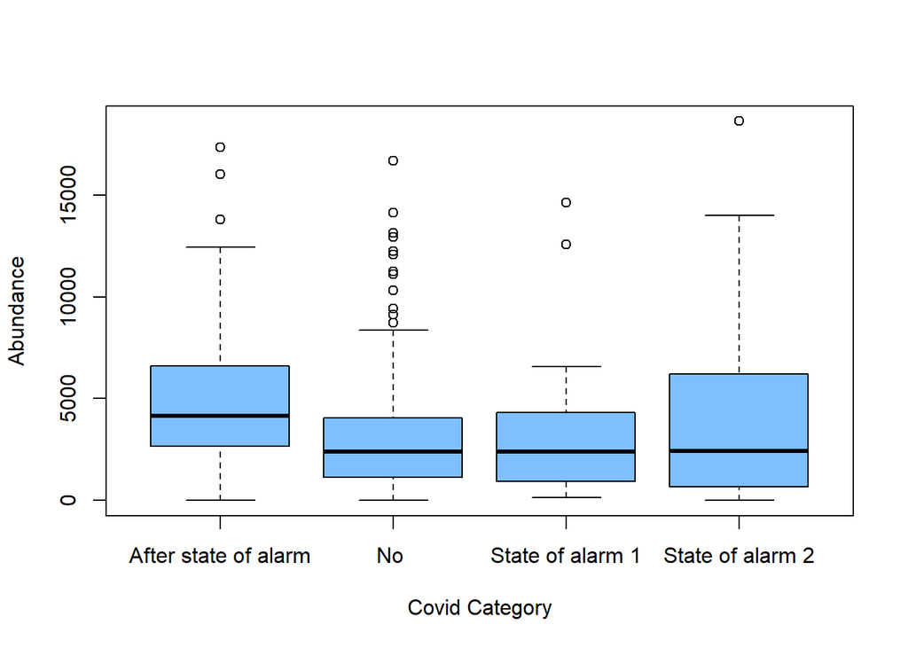

```r
boxplot(data1$kgs~data1$Covid, col = rgb(0, 0.5, 1, alpha = 0.5),xlab="Covid Category",ylab="Abundance")
```

#### 3.1.2.1 Price vs Abundance (scatter plot)

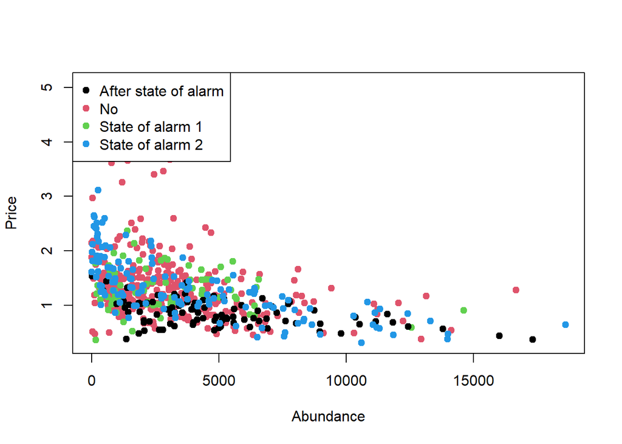

```r
plot(data1$kgs,data1$euros,
     pch = 19,
     col = factor(data1$Covid),xlab="Abundance",ylab = "Price")

# Legend
legend("topleft",
       legend = levels(factor(data1$Covid)),
       pch = 19,
       col = factor(levels(factor(data1$Covid))))
```

```r
cor.test(data1$kgs,data1$euros)
```

```
##
##  Pearson's product-moment correlation
##
## data:  data1$kgs and data1$euros
## t = -11.677, df = 630, p-value < 2.2e-16
## alternative hypothesis: true correlation is not equal to 0
## 95 percent confidence interval:
##  -0.4838764 -0.3555090
## sample estimates:
##        cor
## -0.4218041
```

Is gamma a correct distribution for the response variable PRICE?

```r
summary(data1$euros)
```

```
##    Min. 1st Qu.  Median    Mean 3rd Qu.    Max.
##  0.3065  0.9224  1.1743  1.2680  1.4861  5.0834
```

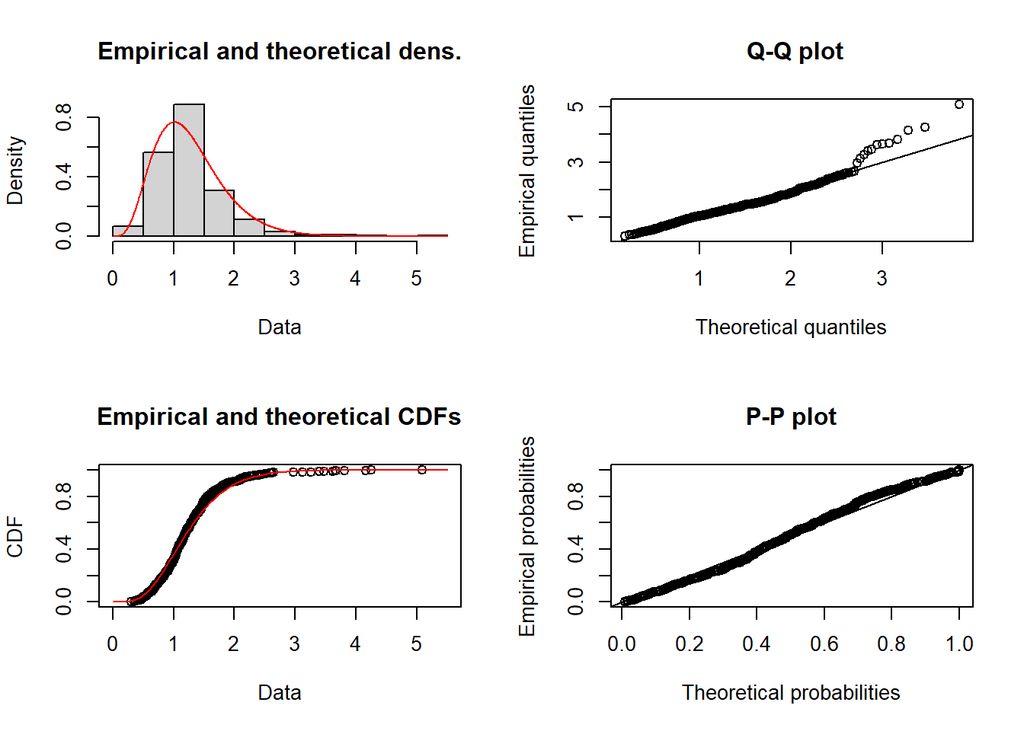

```r
a=fitdist(data1$euros, distr = "gamma",start=list(shape = 1, rate = 2), lower = -1,method = "mme")
plot(a)
```

```r
ks.test(na.omit(data1$euros), "pgamma", a$estimate[1],a$estimate[2])
```

```
##
##  One-sample Kolmogorov-Smirnov test
##
## data:  na.omit(data1$euros)
## D = 0.062833, p-value = 0.01361
## alternative hypothesis: two-sided
```

```r
gamma_test(data1$euros)
```

```
##
##  Test of fit for the Gamma distribution
##
## data:  data1$euros
## V = 8.3713, p-value = 3.231e-09
```

Is gamma a correct distribution for the response variable ABUNDANCE?

```r
summary(data1$kgs)
```

```
##     Min.  1st Qu.   Median     Mean  3rd Qu.     Max.
##     5.16  1168.35  2667.93  3499.14  4816.90 18617.88
```

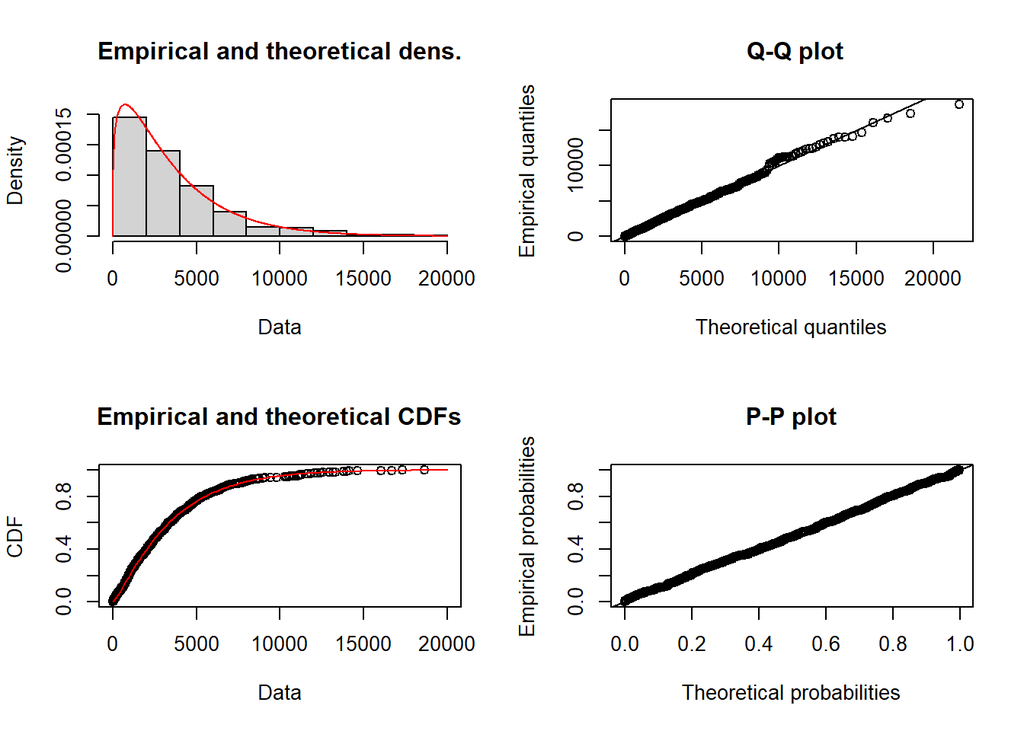

```r
a=fitdist(data1$kgs, distr = "gamma",start=list(shape = 1, rate = 2), lower = -1,method = "mme")
plot(a)
```

```r
ks.test(na.omit(data1$kgs), "pgamma", a$estimate[1],a$estimate[2])
```

```
##
##  One-sample Kolmogorov-Smirnov test
##
## data:  na.omit(data1$kgs)
## D = 0.019868, p-value = 0.9643
## alternative hypothesis: two-sided
```

```r
gamma_test(data1$kgs)
```

```
##
##  Test of fit for the Gamma distribution
##
## data:  data1$kgs
## V = -1.3266, p-value = 0.3482
```

### 3.1.3 Regression model

```r
x=as.factor(data1$Covid)
table(x)
```

```
## x
## After state of alarm                  No      State of alarm 1
##                   94                  321                   75
##     State of alarm 2
##                  142
```

```r
y=as.numeric(data1$euros)
x=relevel(x, ref = "No ")
z=data1$kgs


Model<-glm((y)~x,family=Gamma(link=log))
cooksd <- cooks.distance(Model)
influential <- cooksd[(cooksd > (3 * mean(cooksd, na.rm = TRUE)))]
influential=as.numeric(names(influential))
y=y[-influential]
xaux=x[-influential]
Model<-glm((y)~xaux,family=Gamma(link=log))
summary(Model)
```

```
##
## Call:
## glm(formula = (y) ~ xaux, family = Gamma(link = log))
##
## Deviance Residuals:
##      Min        1Q    Median        3Q       Max
## -1.00247  -0.21854  -0.02599   0.17298   0.81929
##
## Coefficients:
##                          Estimate Std. Error t value Pr(>|t|)
## (Intercept)               0.23106    0.01738  13.294   <2e-16 ***
## xauxAfter state of alarm -0.41497    0.03713 -11.177   <2e-16 ***
## xauxState of alarm 1      0.02389    0.04123   0.579    0.563
## xauxState of alarm 2      0.01618    0.03290   0.492    0.623
## ---
## Signif. codes:  0 '***' 0.001 '**' 0.01 '*' 0.05 '.' 0.1 ' ' 1
##
## (Dispersion parameter for Gamma family taken to be 0.0936432)
##
##     Null deviance: 68.901  on 583  degrees of freedom
## Residual deviance: 56.914  on 580  degrees of freedom
## AIC: 464.89
##
## Number of Fisher Scoring iterations: 4
```

```r
Model.aux<-glm((z)~x,family=Gamma(link=log))

cooksd <- cooks.distance(Model.aux)
influential <- cooksd[(cooksd > (3 * mean(cooksd, na.rm = TRUE)))]
influential=as.numeric(names(influential))
z=z[-influential]
xaux=x[-influential]
Model.aux<-glm((z)~xaux,family=Gamma(link=log))
summary(Model.aux)
```

```
##
## Call:
## glm(formula = (z) ~ xaux, family = Gamma(link = log))
##
## Deviance Residuals:
##     Min       1Q   Median       3Q      Max
## -3.2493  -0.8071  -0.1534   0.3762   1.5466
##
## Coefficients:
##                          Estimate Std. Error t value Pr(>|t|)
## (Intercept)               7.91806    0.04231 187.164  < 2e-16 ***
## xauxAfter state of alarm  0.46272    0.09049   5.114 4.28e-07 ***
## xauxState of alarm 1     -0.15360    0.09988  -1.538    0.125
## xauxState of alarm 2      0.04333    0.07835   0.553    0.580
## ---
## Signif. codes:  0 '***' 0.001 '**' 0.01 '*' 0.05 '.' 0.1 ' ' 1
##
## (Dispersion parameter for Gamma family taken to be 0.5566159)
##
##     Null deviance: 499.34  on 593  degrees of freedom
## Residual deviance: 479.27  on 590  degrees of freedom
## AIC: 10645
##
## Number of Fisher Scoring iterations: 6
```

## 3.2 Trachurus picturatus

```r
data1=subset(data_M,data_M$specie=="JAA-JUREL NEGRO")
```

### 3.2.1 Exploratory analysis

#### 3.2.1.1 Price by covid category (boxplot)

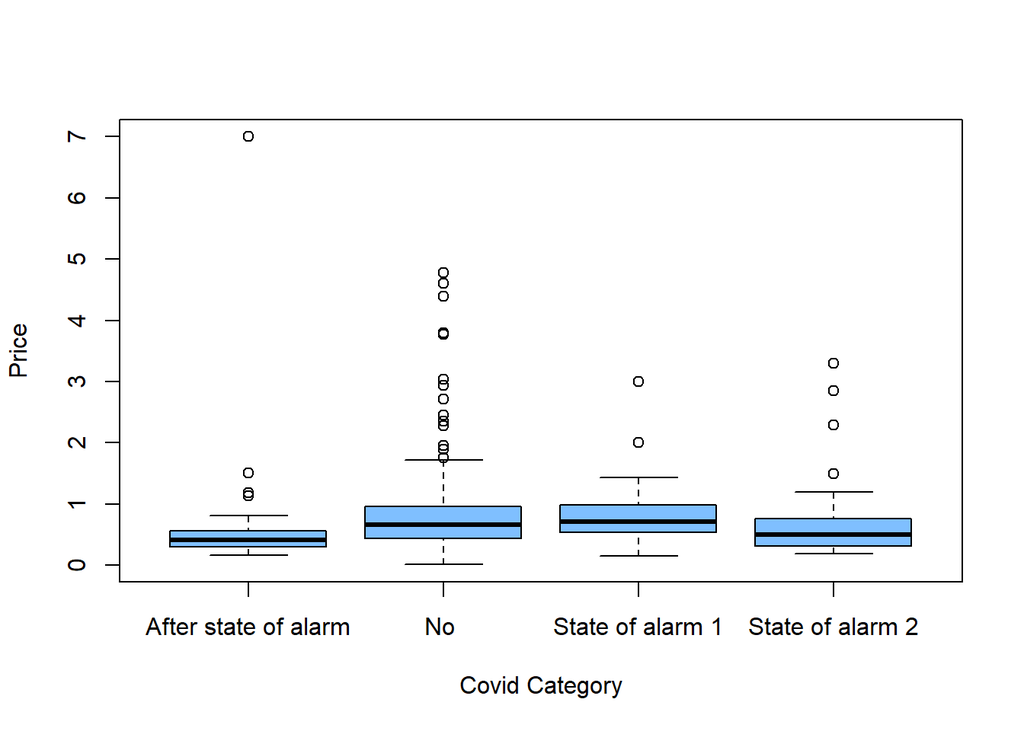

```r
boxplot(data1$euros~data1$Covid, col = rgb(0, 0.5, 1, alpha = 0.5),xlab="Covid Category",ylab="Price")
```

### 3.2.2 Abundance by covid category (boxplot)

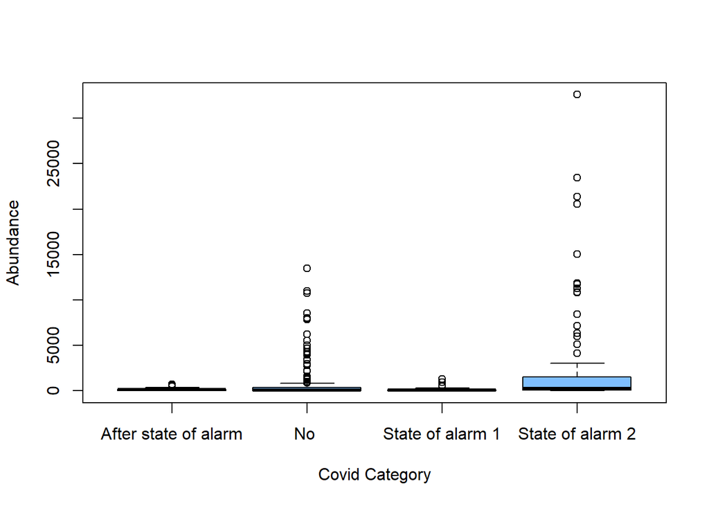

```r
boxplot(data1$kgs~data1$Covid, col = rgb(0, 0.5, 1, alpha = 0.5),xlab="Covid Category",ylab="Abundance")
```

#### 3.2.2.1 Price vs Abundance (scatter plot)

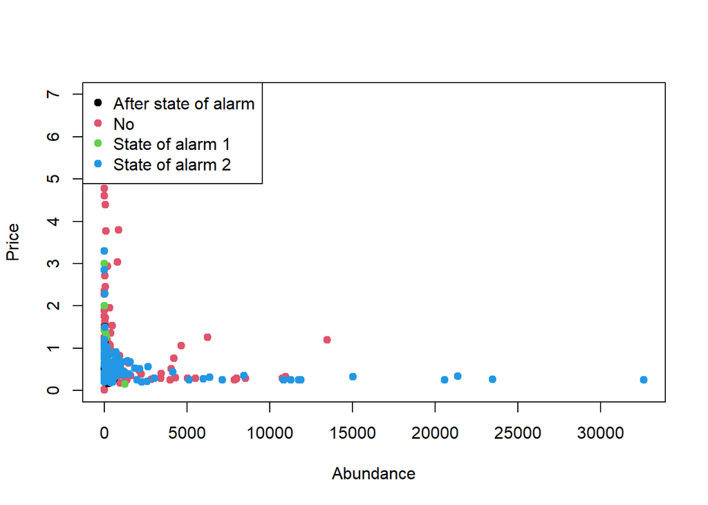

```r
plot(data1$kgs,data1$euros,
     pch = 19,
     col = factor(data1$Covid),xlab="Abundance",ylab = "Price")

# Legend
legend("topleft",
       legend = levels(factor(data1$Covid)),
       pch = 19,
       col = factor(levels(factor(data1$Covid))))
```

```r
cor.test(data1$kgs,data1$euros)
```

```
##
##  Pearson's product-moment correlation
##
## data:  data1$kgs and data1$euros
## t = -3.2051, df = 409, p-value = 0.001456
## alternative hypothesis: true correlation is not equal to 0
## 95 percent confidence interval:
##  -0.24948193 -0.06072013
## sample estimates:
##        cor
## -0.1565301
```

Is gamma a correct distribution for the response variable PRICE?

```r
summary(data1$euros)
```

```
##    Min. 1st Qu.  Median    Mean 3rd Qu.    Max.
##  0.0100  0.3669  0.5978  0.7378  0.8563  7.0000
```

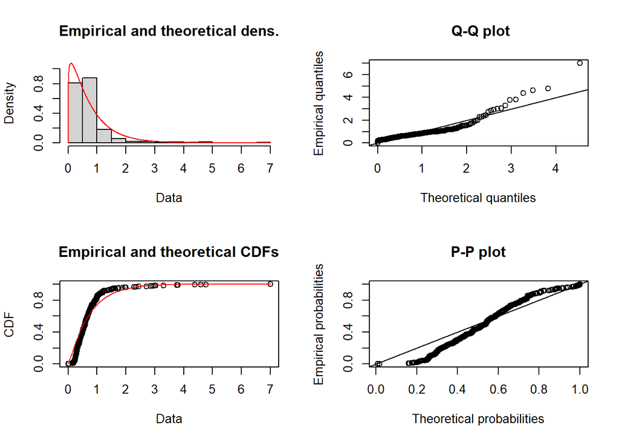

```r
a=fitdist(data1$euros, distr = "gamma",start=list(shape = 1, rate = 2), lower = -1,method = "mme")
plot(a)
```

```r
ks.test(na.omit(data1$euros), "pgamma", a$estimate[1],a$estimate[2])
```

```
##
##  One-sample Kolmogorov-Smirnov test
##
## data:  na.omit(data1$euros)
## D = 0.2007, p-value = 8.327e-15
## alternative hypothesis: two-sided
```

```r
gamma_test(data1$euros)
```

```
##
##  Test of fit for the Gamma distribution
##
## data:  data1$euros
## V = 18.899, p-value < 2.2e-16
```

Is gamma a correct distribution for the response variable ABUNDANCE?

```r
summary(data1$kgs)
```

```
##     Min.  1st Qu.   Median     Mean  3rd Qu.     Max.
##     2.10    30.68   104.76  1027.55   409.90 32598.40
```

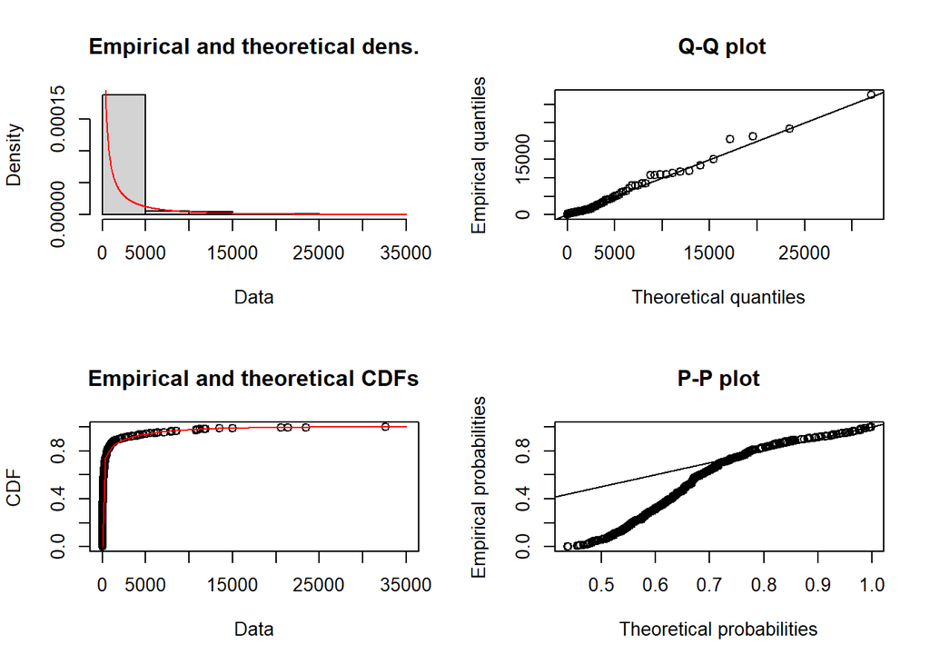

```r
a=fitdist(data1$kgs, distr = "gamma",start=list(shape = 1, rate = 2), lower = -1,method = "mme")
plot(a)
```

```r
ks.test(na.omit(data1$kgs), "pgamma", a$estimate[1],a$estimate[2])
```

```
##
##  One-sample Kolmogorov-Smirnov test
##
## data:  na.omit(data1$kgs)
## D = 0.45607, p-value < 2.2e-16
## alternative hypothesis: two-sided
```

```r
gamma_test(data1$kgs)
```

```
##
##  Test of fit for the Gamma distribution
##
## data:  data1$kgs
## V = 15.555, p-value < 2.2e-16
```

### 3.2.3 Regression model

```r
x=as.factor(data1$Covid)
table(x)
```

```
## x
## After state of alarm                  No      State of alarm 1
##                   60                  210                   43
##     State of alarm 2
##                   98
```

```r
y=as.numeric(data1$euros)
x=relevel(x, ref = "No ")
z=data1$kgs


Model<-glm((y)~x,family=Gamma(link=log))
cooksd <- cooks.distance(Model)
influential <- cooksd[(cooksd > (3 * mean(cooksd, na.rm = TRUE)))]
influential=as.numeric(names(influential))
y=y[-influential]
xaux=x[-influential]
Model<-glm((y)~xaux,family=Gamma(link=log))
summary(Model)
```

```
##
## Call:
## glm(formula = (y) ~ xaux, family = Gamma(link = log))
##
## Deviance Residuals:
##     Min       1Q   Median       3Q      Max
## -2.5744  -0.4587  -0.1005   0.2446   1.7870
##
## Coefficients:
##                          Estimate Std. Error t value Pr(>|t|)
## (Intercept)              -0.30491    0.03908  -7.801 5.55e-14 ***
## xauxAfter state of alarm -0.50913    0.08307  -6.129 2.15e-09 ***
## xauxState of alarm 1     -0.02238    0.09554  -0.234    0.815
## xauxState of alarm 2     -0.31117    0.06934  -4.488 9.46e-06 ***
## ---
## Signif. codes:  0 '***' 0.001 '**' 0.01 '*' 0.05 '.' 0.1 ' ' 1
##
## (Dispersion parameter for Gamma family taken to be 0.3116229)
##
##     Null deviance: 133.13  on 397  degrees of freedom
## Residual deviance: 118.72  on 394  degrees of freedom
## AIC: 196.31
##
## Number of Fisher Scoring iterations: 5
```

```r
Model.aux<-glm((z)~x,family=Gamma(link=log))

cooksd <- cooks.distance(Model.aux)
influential <- cooksd[(cooksd > (3 * mean(cooksd, na.rm = TRUE)))]
influential=as.numeric(names(influential))
z=z[-influential]
xaux=x[-influential]
Model.aux<-glm((z)~xaux,family=Gamma(link=log))
summary(Model.aux)
```

```
##
## Call:
## glm(formula = (z) ~ xaux, family = Gamma(link = log))
##
## Deviance Residuals:
##     Min       1Q   Median       3Q      Max
## -3.2477  -1.7092  -1.0188   0.0172   4.1846
##
## Coefficients:
##                          Estimate Std. Error t value Pr(>|t|)
## (Intercept)                5.8596     0.1355  43.250  < 2e-16 ***
## xauxAfter state of alarm  -0.9971     0.2852  -3.496 0.000527 ***
## xauxState of alarm 1      -1.2926     0.3312  -3.903 0.000112 ***
## xauxState of alarm 2       1.1543     0.2428   4.755 2.82e-06 ***
## ---
## Signif. codes:  0 '***' 0.001 '**' 0.01 '*' 0.05 '.' 0.1 ' ' 1
##
## (Dispersion parameter for Gamma family taken to be 3.652718)
##
##     Null deviance: 1202.56  on 386  degrees of freedom
## Residual deviance:  967.32  on 383  degrees of freedom
## AIC: 5163.6
##
## Number of Fisher Scoring iterations: 9
```

## 3.3 Trachurus trachurus

```r
data1=subset(data_M,data_M$specie=="HOM-JUREL")
```

### 3.3.1 Exploratory analysis

#### 3.3.1.1 Price by covid category (boxplot)

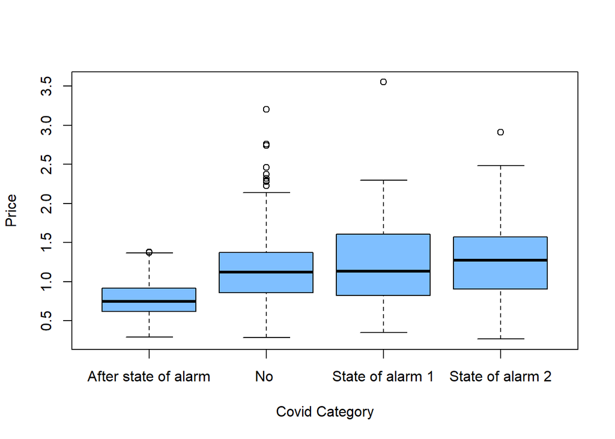

```r
boxplot(data1$euros~data1$Covid, col = rgb(0, 0.5, 1, alpha = 0.5),xlab="Covid Category",ylab="Price")
```

### 3.3.2 Abundance by covid category (boxplot)

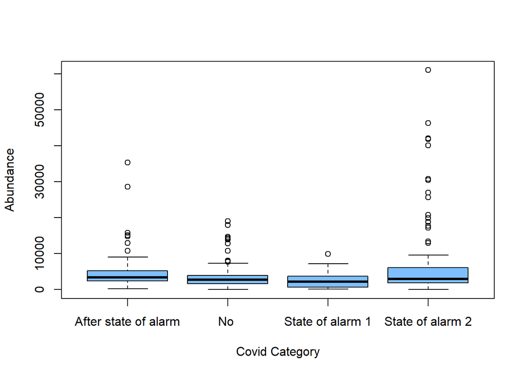

```r
boxplot(data1$kgs~data1$Covid, col = rgb(0, 0.5, 1, alpha = 0.5),xlab="Covid Category",ylab="Abundance")
```

#### 3.3.2.1 Price vs Abundance (scatter plot)

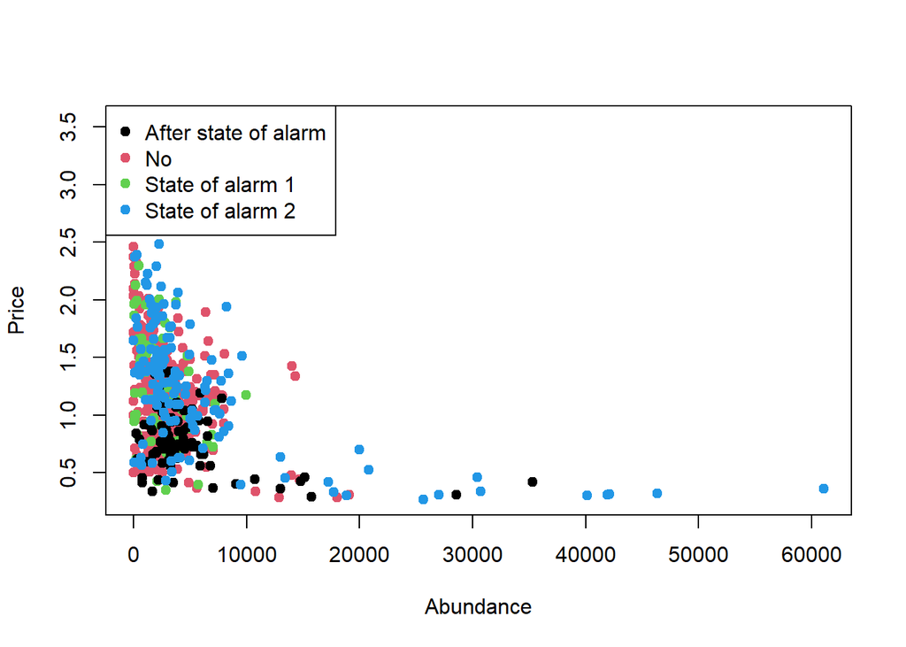

```r
plot(data1$kgs,data1$euros,
     pch = 19,
     col = factor(data1$Covid),xlab="Abundance",ylab = "Price")

# Legend
legend("topleft",
       legend = levels(factor(data1$Covid)),
       pch = 19,
       col = factor(levels(factor(data1$Covid))))
```

```r
cor.test(data1$kgs,data1$euros)
```

```
##
##  Pearson's product-moment correlation
##
## data:  data1$kgs and data1$euros
## t = -10.062, df = 614, p-value < 2.2e-16
## alternative hypothesis: true correlation is not equal to 0
## 95 percent confidence interval:
##  -0.4421042 -0.3063558
## sample estimates:
##        cor
## -0.3762474
```

Is gamma a correct distribution for the response variable PRICE?

```r
summary(data1$euros)
```

```
##    Min. 1st Qu.  Median    Mean 3rd Qu.    Max.
##  0.2681  0.7735  1.0805  1.1317  1.3881  3.5500
```

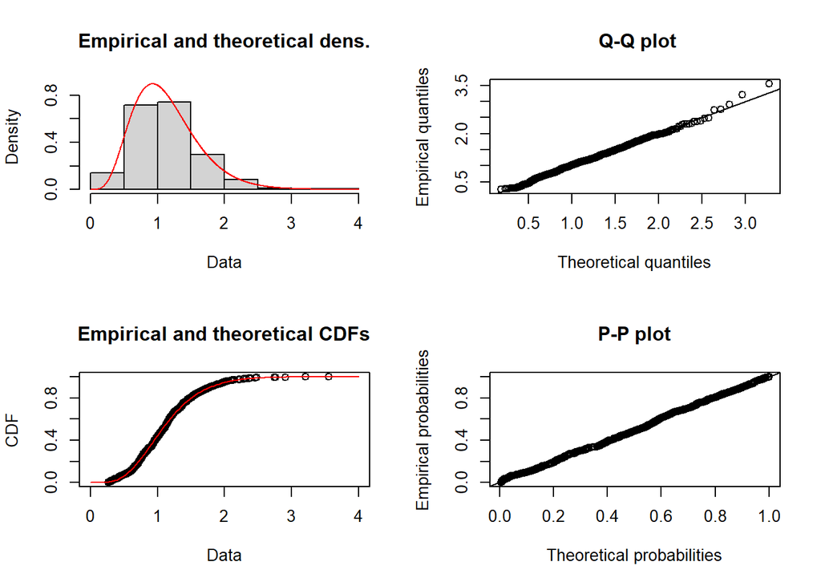

```r
a=fitdist(data1$euros, distr = "gamma",start=list(shape = 1, rate = 2), lower = -1,method = "mme")
plot(a)
```

```r
ks.test(na.omit(data1$euros), "pgamma", a$estimate[1],a$estimate[2])
```

```
##
##  One-sample Kolmogorov-Smirnov test
##
## data:  na.omit(data1$euros)
## D = 0.024985, p-value = 0.8366
## alternative hypothesis: two-sided
```

```r
gamma_test(data1$euros)
```

```
##
##  Test of fit for the Gamma distribution
##
## data:  data1$euros
## V = -0.37832, p-value = 0.7891
```

Is gamma a correct distribution for the response variable ABUNDANCE?

```r
summary(data1$kgs)
```

```
##    Min. 1st Qu.  Median    Mean 3rd Qu.    Max.
##     1.4  1689.8  2862.7  4011.8  4351.7 61073.8
```

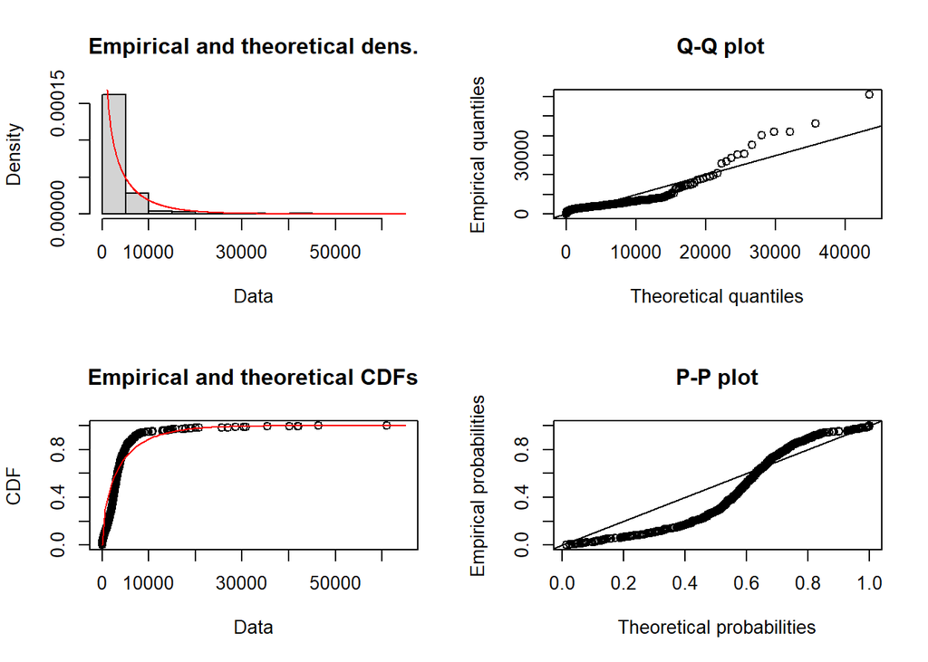

```r
a=fitdist(data1$kgs, distr = "gamma",start=list(shape = 1, rate = 2), lower = -1,method = "mme")
plot(a)
```

```r
ks.test(na.omit(data1$kgs), "pgamma", a$estimate[1],a$estimate[2])
```

```
##
##  One-sample Kolmogorov-Smirnov test
##
## data:  na.omit(data1$kgs)
## D = 0.23615, p-value < 2.2e-16
## alternative hypothesis: two-sided
```

```r
gamma_test(data1$kgs)
```

```
##
##  Test of fit for the Gamma distribution
##
## data:  data1$kgs
## V = 19.582, p-value < 2.2e-16
```

### 3.3.3 Regression model

```r
x=as.factor(data1$Covid)
table(x)
```

```
## x
## After state of alarm                  No      State of alarm 1
##                   89                  325                   68
##     State of alarm 2
##                  134
```

```r
y=as.numeric(data1$euros)
x=relevel(x, ref = "No ")
z=data1$kgs


Model<-glm((y)~x,family=Gamma(link=log))
cooksd <- cooks.distance(Model)
influential <- cooksd[(cooksd > (3 * mean(cooksd, na.rm = TRUE)))]
influential=as.numeric(names(influential))
y=y[-influential]
xaux=x[-influential]
Model<-glm((y)~xaux,family=Gamma(link=log))
summary(Model)
```

```
##
## Call:
## glm(formula = (y) ~ xaux, family = Gamma(link = log))
##
## Deviance Residuals:
##      Min        1Q    Median        3Q       Max
## -1.11569  -0.24483  -0.01115   0.19336   0.80132
##
## Coefficients:
##                          Estimate Std. Error t value Pr(>|t|)
## (Intercept)               0.12139    0.01817   6.682 5.73e-11 ***
## xauxAfter state of alarm -0.39516    0.04098  -9.642  < 2e-16 ***
## xauxState of alarm 1      0.00682    0.04813   0.142  0.88736
## xauxState of alarm 2      0.11298    0.03576   3.160  0.00166 **
## ---
## Signif. codes:  0 '***' 0.001 '**' 0.01 '*' 0.05 '.' 0.1 ' ' 1
##
## (Dispersion parameter for Gamma family taken to be 0.1052716)
##
##     Null deviance: 75.977  on 560  degrees of freedom
## Residual deviance: 64.033  on 557  degrees of freedom
## AIC: 431.49
##
## Number of Fisher Scoring iterations: 4
```

```r
Model.aux<-glm((z)~x,family=Gamma(link=log))

cooksd <- cooks.distance(Model.aux)
influential <- cooksd[(cooksd > (3 * mean(cooksd, na.rm = TRUE)))]
influential=as.numeric(names(influential))
z=z[-influential]
xaux=x[-influential]
Model.aux<-glm((z)~xaux,family=Gamma(link=log))
summary(Model.aux)
```

```
##
## Call:
## glm(formula = (z) ~ xaux, family = Gamma(link = log))
##
## Deviance Residuals:
##     Min       1Q   Median       3Q      Max
## -3.6422  -0.5631  -0.0977   0.3171   2.1509
##
## Coefficients:
##                          Estimate Std. Error t value Pr(>|t|)
## (Intercept)               7.96886    0.03805 209.437  < 2e-16 ***
## xauxAfter state of alarm  0.23725    0.08363   2.837 0.004715 **
## xauxState of alarm 1     -0.34308    0.09420  -3.642 0.000295 ***
## xauxState of alarm 2      0.19646    0.07247   2.711 0.006913 **
## ---
## Signif. codes:  0 '***' 0.001 '**' 0.01 '*' 0.05 '.' 0.1 ' ' 1
##
## (Dispersion parameter for Gamma family taken to be 0.4603763)
##
##     Null deviance: 454.27  on 583  degrees of freedom
## Residual deviance: 439.22  on 580  degrees of freedom
## AIC: 10486
##
## Number of Fisher Scoring iterations: 5
```

## 3.4 Scomber scombrus

```r
data1=subset(data_M,data_M$specie=="MAC-CABALLA")
```

### 3.4.1 Exploratory analysis

#### 3.4.1.1 Price by covid category (boxplot)

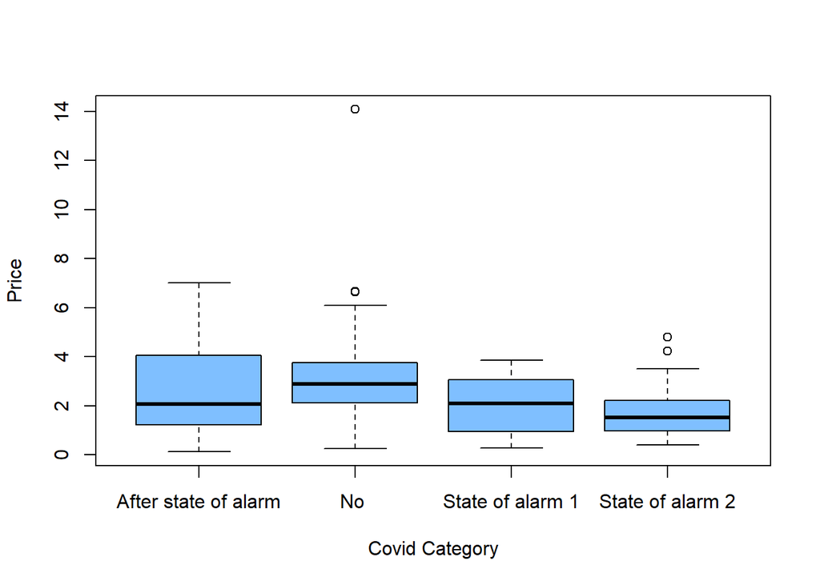

```r
boxplot(data1$euros~data1$Covid, col = rgb(0, 0.5, 1, alpha = 0.5),xlab="Covid Category",ylab="Price")
```

### 3.4.2 Abundance by covid category (boxplot)

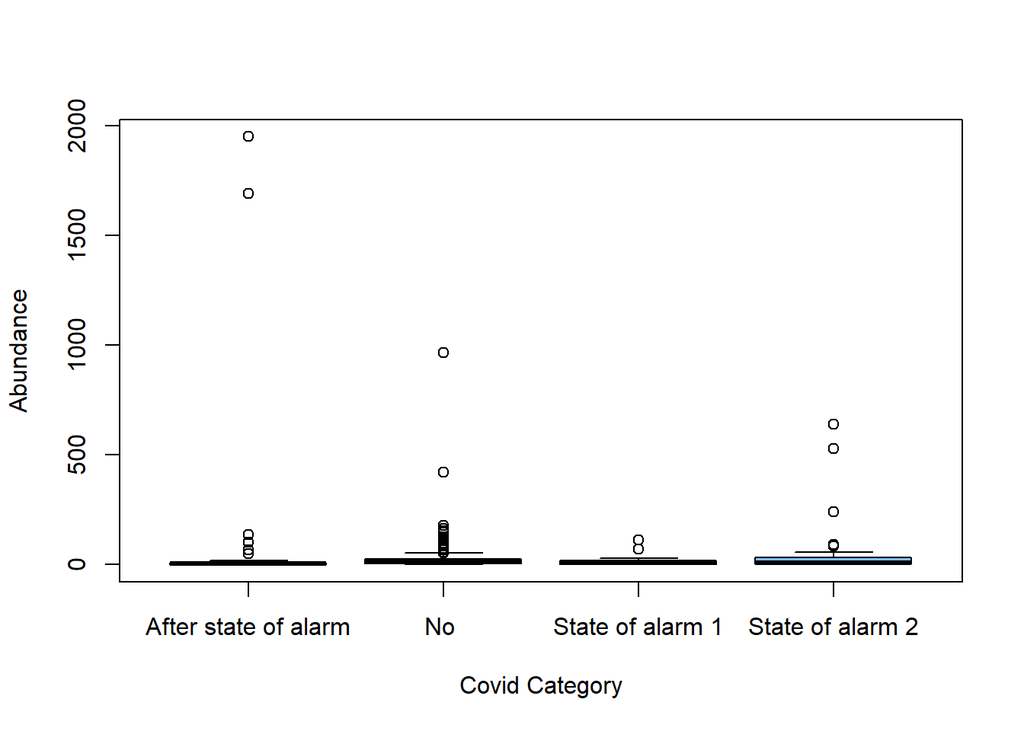

```r
boxplot(data1$kgs~data1$Covid, col = rgb(0, 0.5, 1, alpha = 0.5),xlab="Covid Category",ylab="Abundance")
```

#### 3.4.2.1 Price vs Abundance (scatter plot)

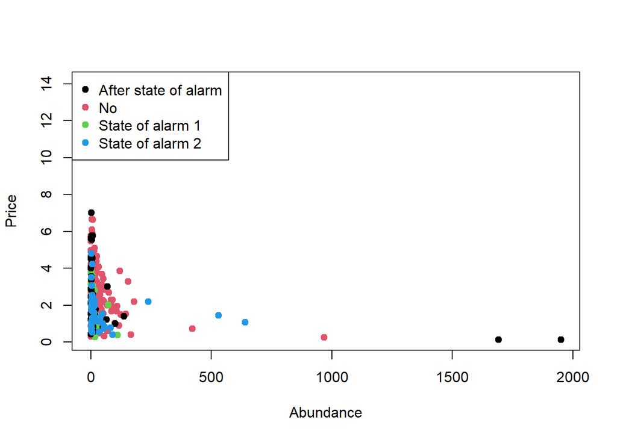

```r
plot(data1$kgs,data1$euros,
     pch = 19,
     col = factor(data1$Covid),xlab="Abundance",ylab = "Price")

# Legend
legend("topleft",
       legend = levels(factor(data1$Covid)),
       pch = 19,
       col = factor(levels(factor(data1$Covid))))
```

```r
cor.test(data1$kgs,data1$euros)
```

```
##
##  Pearson's product-moment correlation
##
## data:  data1$kgs and data1$euros
## t = -4.4395, df = 350, p-value = 1.21e-05
## alternative hypothesis: true correlation is not equal to 0
## 95 percent confidence interval:
##  -0.3275147 -0.1294819
## sample estimates:
##       cor
## -0.230888
```

Is gamma a correct distribution for the response variable PRICE?

```r
summary(data1$euros)
```

```
##    Min. 1st Qu.  Median    Mean 3rd Qu.    Max.
##  0.1257  1.7909  2.5685  2.7408  3.6025 14.0813
```

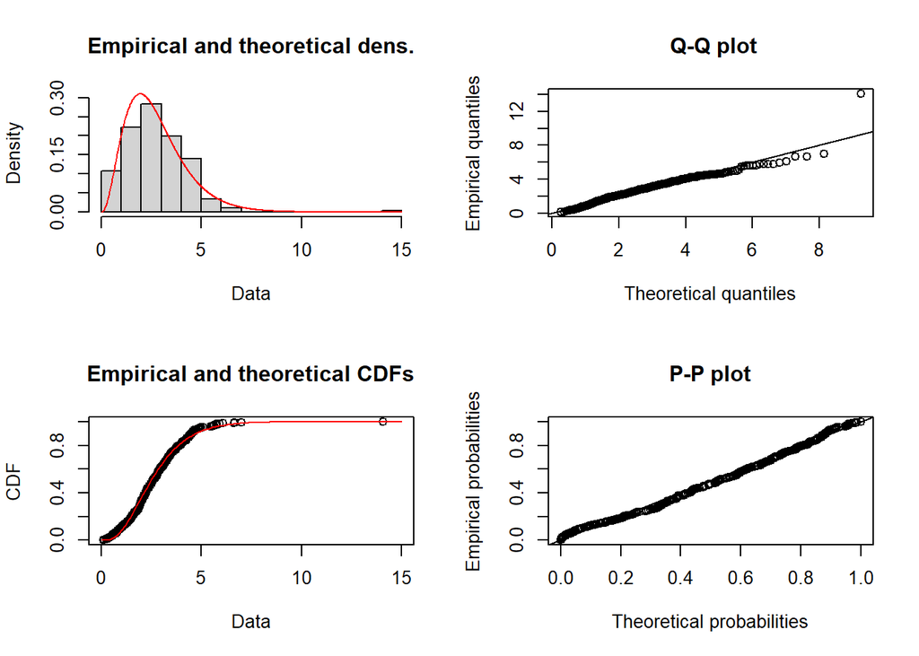

```r
a=fitdist(data1$euros, distr = "gamma",start=list(shape = 1, rate = 2), lower = -1,method = "mme")
plot(a)
```

```r
ks.test(na.omit(data1$euros), "pgamma", a$estimate[1],a$estimate[2])
```

```
##
##  One-sample Kolmogorov-Smirnov test
##
## data:  na.omit(data1$euros)
## D = 0.051961, p-value = 0.2979
## alternative hypothesis: two-sided
```

```r
gamma_test(data1$euros)
```

```
##
##  Test of fit for the Gamma distribution
##
## data:  data1$euros
## V = -2.2405, p-value = 0.1131
```

Is gamma a correct distribution for the response variable ABUNDANCE?

```r
summary(data1$kgs)
```

```
##     Min.  1st Qu.   Median     Mean  3rd Qu.     Max.
##    0.420    3.585    8.260   36.815   21.075 1951.080
```

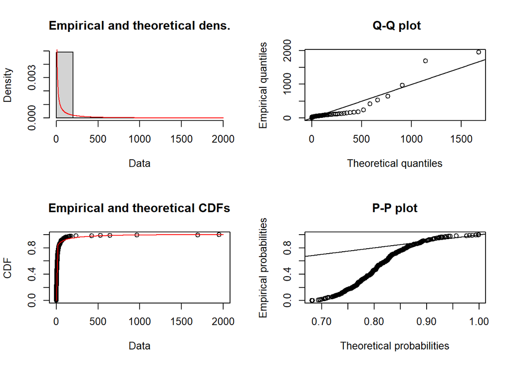

```r
a=fitdist(data1$kgs, distr = "gamma",start=list(shape = 1, rate = 2), lower = -1,method = "mme")
plot(a)
```

```r
ks.test(na.omit(data1$kgs), "pgamma", a$estimate[1],a$estimate[2])
```

```
##
##  One-sample Kolmogorov-Smirnov test
##
## data:  na.omit(data1$kgs)
## D = 0.68768, p-value < 2.2e-16
## alternative hypothesis: two-sided
```

```r
gamma_test(data1$kgs)
```

```
##
##  Test of fit for the Gamma distribution
##
## data:  data1$kgs
## V = 49.795, p-value < 2.2e-16
```

### 3.4.3 Regression model

```r
x=as.factor(data1$Covid)
table(x)
```

```
## x
## After state of alarm                  No      State of alarm 1
##                   54                  233                   22
##     State of alarm 2
##                   43
```

```r
y=as.numeric(data1$euros)
x=relevel(x, ref = "No ")
z=data1$kgs


Model<-glm((y)~x,family=Gamma(link=log))
cooksd <- cooks.distance(Model)
influential <- cooksd[(cooksd > (3 * mean(cooksd, na.rm = TRUE)))]
influential=as.numeric(names(influential))
y=y[-influential]
xaux=x[-influential]
Model<-glm((y)~xaux,family=Gamma(link=log))
summary(Model)
```

```
##
## Call:
## glm(formula = (y) ~ xaux, family = Gamma(link = log))
##
## Deviance Residuals:
##      Min        1Q    Median        3Q       Max
## -1.77156  -0.35548  -0.04668   0.25925   0.92768
##
## Coefficients:
##                          Estimate Std. Error t value Pr(>|t|)
## (Intercept)               1.09231    0.02758  39.599  < 2e-16 ***
## xauxAfter state of alarm -0.24369    0.07046  -3.459 0.000616 ***
## xauxState of alarm 1     -0.31400    0.12965  -2.422 0.015997 *
## xauxState of alarm 2     -0.69671    0.07353  -9.475  < 2e-16 ***
## ---
## Signif. codes:  0 '***' 0.001 '**' 0.01 '*' 0.05 '.' 0.1 ' ' 1
##
## (Dispersion parameter for Gamma family taken to be 0.1765293)
##
##     Null deviance: 83.848  on 322  degrees of freedom
## Residual deviance: 68.955  on 319  degrees of freedom
## AIC: 995.68
##
## Number of Fisher Scoring iterations: 4
```

```r
Model.aux<-glm((z)~x,family=Gamma(link=log))

cooksd <- cooks.distance(Model.aux)
influential <- cooksd[(cooksd > (3 * mean(cooksd, na.rm = TRUE)))]
influential=as.numeric(names(influential))
z=z[-influential]
xaux=x[-influential]
Model.aux<-glm((z)~xaux,family=Gamma(link=log))
summary(Model.aux)
```

```
##
## Call:
## glm(formula = (z) ~ xaux, family = Gamma(link = log))
##
## Deviance Residuals:
##     Min       1Q   Median       3Q      Max
## -2.4182  -1.2718  -0.7537   0.0603   3.9177
##
## Coefficients:
##                          Estimate Std. Error t value Pr(>|t|)
## (Intercept)               3.03626    0.09988  30.400   <2e-16 ***
## xauxAfter state of alarm -0.51343    0.23300  -2.204   0.0282 *
## xauxState of alarm 1     -0.84853    0.35383  -2.398   0.0170 *
## xauxState of alarm 2     -0.18242    0.25997  -0.702   0.4833
## ---
## Signif. codes:  0 '***' 0.001 '**' 0.01 '*' 0.05 '.' 0.1 ' ' 1
##
## (Dispersion parameter for Gamma family taken to be 2.304345)
##
##     Null deviance: 543.81  on 342  degrees of freedom
## Residual deviance: 524.66  on 339  degrees of freedom
## AIC: 2668.2
##
## Number of Fisher Scoring iterations: 7
```

## 3.5 Sardina pilchardus

```r
data1=subset(data_M,data_M$specie=="PIL-SARDINA")
```

### 3.5.1 Exploratory analysis

#### 3.5.1.1 Price by covid category (boxplot)

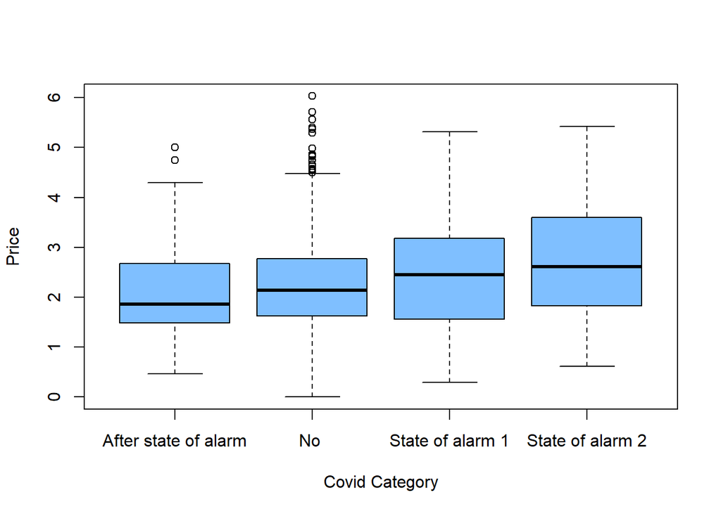

```r
boxplot(data1$euros~data1$Covid, col = rgb(0, 0.5, 1, alpha = 0.5),xlab="Covid Category",ylab="Price")
```

### 3.5.2 Abundance by covid category (boxplot)

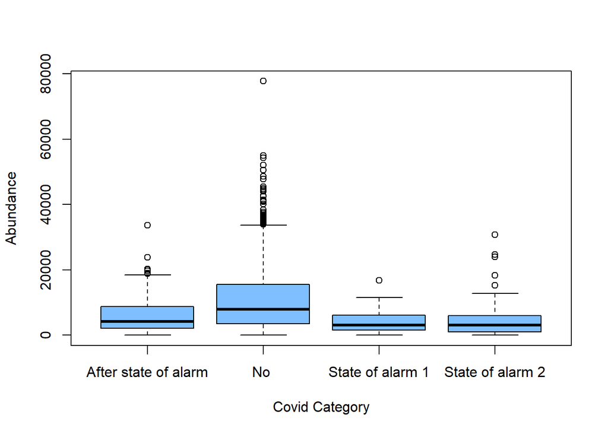

```r
boxplot(data1$kgs~data1$Covid, col = rgb(0, 0.5, 1, alpha = 0.5),xlab="Covid Category",ylab="Abundance")
```

#### 3.5.2.1 Price vs Abundance (scatter plot)

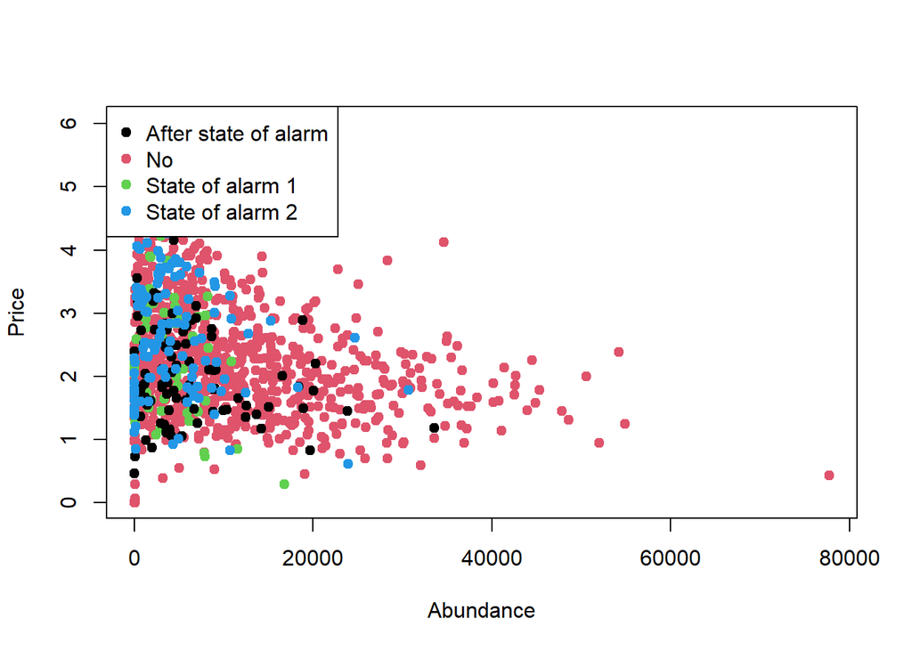

```r
plot(data1$kgs,data1$euros,
     pch = 19,
     col = factor(data1$Covid),xlab="Abundance",ylab = "Price")

# Legend
legend("topleft",
       legend = levels(factor(data1$Covid)),
       pch = 19,
       col = factor(levels(factor(data1$Covid))))
```

```r
cor.test(data1$kgs,data1$euros)
```

```
##
##  Pearson's product-moment correlation
##
## data:  data1$kgs and data1$euros
## t = -9.7935, df = 1093, p-value < 2.2e-16
## alternative hypothesis: true correlation is not equal to 0
## 95 percent confidence interval:
##  -0.3375901 -0.2286341
## sample estimates:
##        cor
## -0.2840288
```

Is gamma a correct distribution for the response variable PRICE?

```r
summary(data1$euros)
```

```
##    Min. 1st Qu.  Median    Mean 3rd Qu.    Max.
##   0.000   1.632   2.171   2.321   2.908   6.030
```

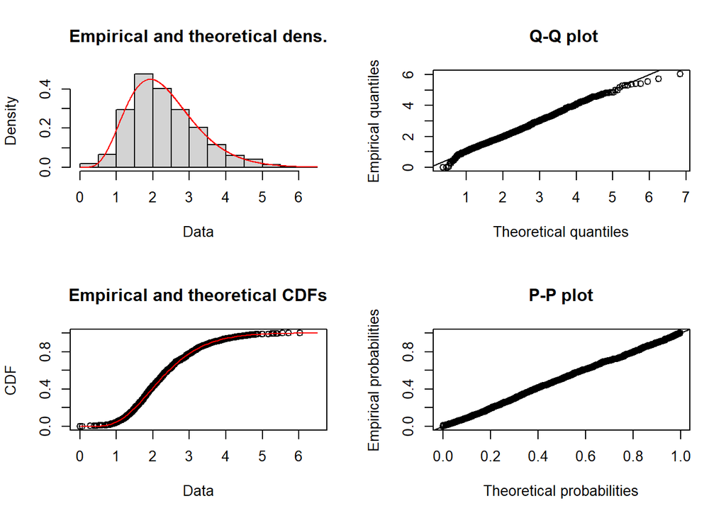

```r
a=fitdist(data1$euros, distr = "gamma",start=list(shape = 1, rate = 2), lower = -1,method = "mme")
plot(a)
```

```r
ks.test(na.omit(data1$euros), "pgamma", a$estimate[1],a$estimate[2])
```

```
##
##  One-sample Kolmogorov-Smirnov test
##
## data:  na.omit(data1$euros)
## D = 0.017756, p-value = 0.8803
## alternative hypothesis: two-sided
```

```r
gamma_test(data1$euros)
```

```
##
##  Test of fit for the Gamma distribution
##
## data:  data1$euros
## V = NaN, p-value = NA
```

Is gamma a correct distribution for the response variable ABUNDANCE?

```r
summary(data1$kgs)
```

```
##    Min. 1st Qu.  Median    Mean 3rd Qu.    Max.
##     2.6  2757.4  6406.2  9675.1 13576.4 77750.8
```

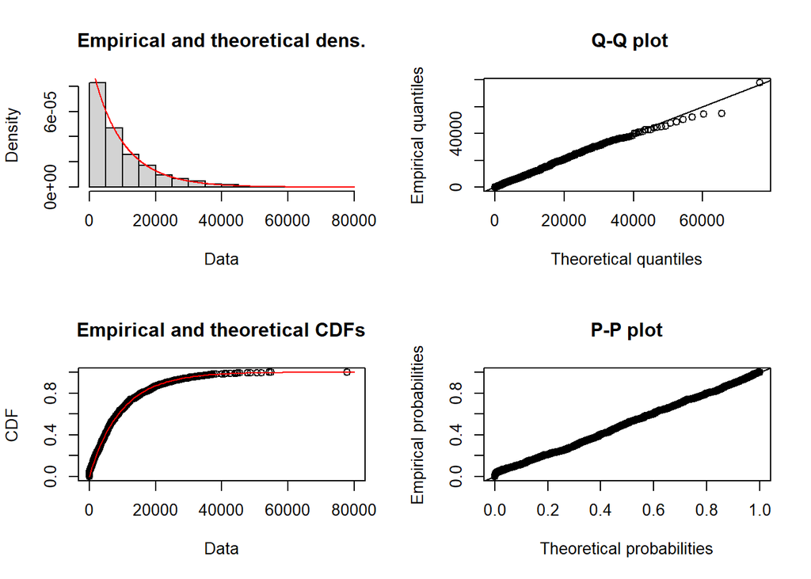

```r
a=fitdist(data1$kgs, distr = "gamma",start=list(shape = 1, rate = 2), lower = -1,method = "mme")
plot(a)
```

```r
ks.test(na.omit(data1$kgs), "pgamma", a$estimate[1],a$estimate[2])
```

```
##
##  One-sample Kolmogorov-Smirnov test
##
## data:  na.omit(data1$kgs)
## D = 0.037939, p-value = 0.08551
## alternative hypothesis: two-sided
```

```r
gamma_test(data1$kgs)
```

```
##
##  Test of fit for the Gamma distribution
##
## data:  data1$kgs
## V = -3.9788, p-value = 0.004902
```

### 3.5.3 Regression model

```r
ind=which(data1$euros==0)
data1=data1[-ind,]
x=as.factor(data1$Covid)
table(x)
```

```
## x
## After state of alarm                  No      State of alarm 1
##                   88                  830                   55
##     State of alarm 2
##                  120
```

```r
y=as.numeric(data1$euros)
x=relevel(x, ref = "No ")
z=data1$kgs

ind=which(y==0)


Model<-glm((y)~x,family=Gamma(link=log))
cooksd <- cooks.distance(Model)
influential <- cooksd[(cooksd > (3 * mean(cooksd, na.rm = TRUE)))]
influential=as.numeric(names(influential))
y=y[-influential]
xaux=x[-influential]
Model<-glm((y)~xaux,family=Gamma(link=log))
summary(Model)
```

```
##
## Call:
## glm(formula = (y) ~ xaux, family = Gamma(link = log))
##
## Deviance Residuals:
##      Min        1Q    Median        3Q       Max
## -2.97364  -0.29230  -0.04885   0.20955   0.91614
##
## Coefficients:
##                          Estimate Std. Error t value Pr(>|t|)
## (Intercept)               0.81166    0.01272  63.825  < 2e-16 ***
## xauxAfter state of alarm -0.11566    0.04737  -2.442   0.0148 *
## xauxState of alarm 1      0.14448    0.07139   2.024   0.0433 *
## xauxState of alarm 2      0.16979    0.03955   4.293 1.94e-05 ***
## ---
## Signif. codes:  0 '***' 0.001 '**' 0.01 '*' 0.05 '.' 0.1 ' ' 1
##
## (Dispersion parameter for Gamma family taken to be 0.1332587)
##
##     Null deviance: 155.36  on 1009  degrees of freedom
## Residual deviance: 151.26  on 1006  degrees of freedom
## AIC: 2497.3
##
## Number of Fisher Scoring iterations: 4
```

```r
Model.aux<-glm((z)~x,family=Gamma(link=log))

cooksd <- cooks.distance(Model.aux)
influential <- cooksd[(cooksd > (3 * mean(cooksd, na.rm = TRUE)))]
influential=as.numeric(names(influential))
z=z[-influential]
xaux=x[-influential]
Model.aux<-glm((z)~xaux,family=Gamma(link=log))
summary(Model.aux)
```

```
##
## Call:
## glm(formula = (z) ~ xaux, family = Gamma(link = log))
##
## Deviance Residuals:
##     Min       1Q   Median       3Q      Max
## -3.7067  -0.9272  -0.2371   0.3920   1.8577
##
## Coefficients:
##                          Estimate Std. Error t value Pr(>|t|)
## (Intercept)               9.28053    0.03012 308.167  < 2e-16 ***
## xauxAfter state of alarm -0.87063    0.10744  -8.103 1.50e-15 ***
## xauxState of alarm 1     -1.20161    0.14694  -8.178 8.44e-16 ***
## xauxState of alarm 2     -1.22388    0.08832 -13.857  < 2e-16 ***
## ---
## Signif. codes:  0 '***' 0.001 '**' 0.01 '*' 0.05 '.' 0.1 ' ' 1
##
## (Dispersion parameter for Gamma family taken to be 0.7445912)
##
##     Null deviance: 1439.4  on 1034  degrees of freedom
## Residual deviance: 1272.3  on 1031  degrees of freedom
## AIC: 20830
##
## Number of Fisher Scoring iterations: 6
```

## 3.6 Scomber colias

```r
data1=subset(data_M,data_M$specie=="VMA-CABALLA DEL SUR O TONINO")
```

### 3.6.1 Exploratory analysis

#### 3.6.1.1 Price by covid category (boxplot)

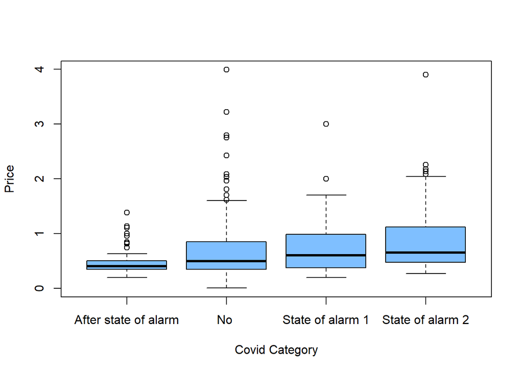

```r
boxplot(data1$euros~data1$Covid, col = rgb(0, 0.5, 1, alpha = 0.5),xlab="Covid Category",ylab="Price")
```

### 3.6.2 Abundance by covid category (boxplot)

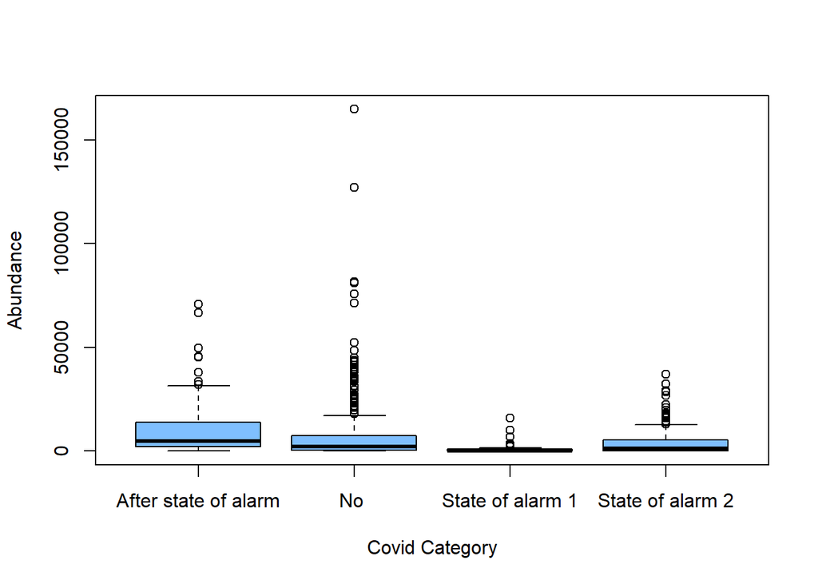

```r
boxplot(data1$kgs~data1$Covid, col = rgb(0, 0.5, 1, alpha = 0.5),xlab="Covid Category",ylab="Abundance")
```

#### 3.6.2.1 Price vs Abundance (scatter plot)

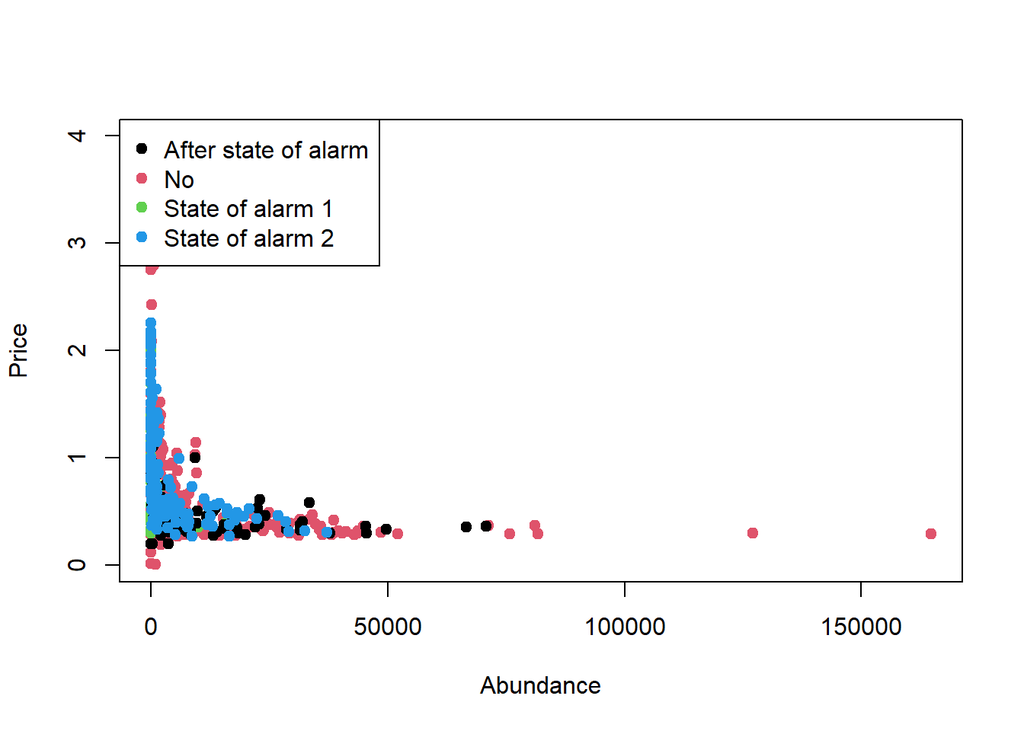

```r
plot(data1$kgs,data1$euros,
     pch = 19,
     col = factor(data1$Covid),xlab="Abundance",ylab = "Price")

# Legend
legend("topleft",
       legend = levels(factor(data1$Covid)),
       pch = 19,
       col = factor(levels(factor(data1$Covid))))
```

```r
cor.test(data1$kgs,data1$euros)
```

```
##
##  Pearson's product-moment correlation
##
## data:  data1$kgs and data1$euros
## t = -7.5421, df = 602, p-value = 1.713e-13
## alternative hypothesis: true correlation is not equal to 0
## 95 percent confidence interval:
##  -0.3650458 -0.2191833
## sample estimates:
##        cor
## -0.2938242
```

Is gamma a correct distribution for the response variable PRICE?

```r
summary(data1$euros)
```

```
##     Min.  1st Qu.   Median     Mean  3rd Qu.     Max.
## 0.004599 0.366241 0.511800 0.684316 0.869548 3.989307
```

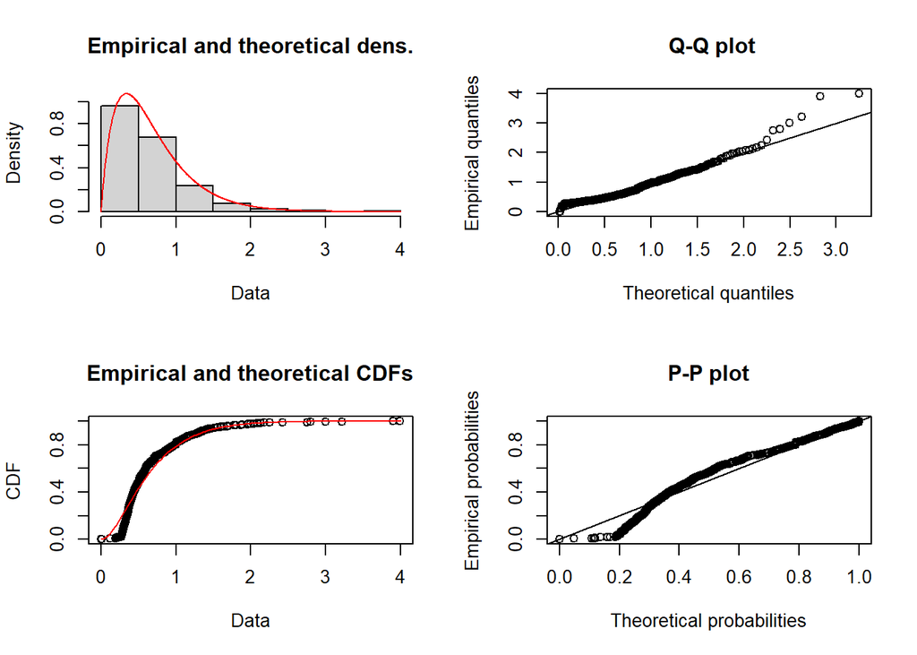

```r
a=fitdist(data1$euros, distr = "gamma",start=list(shape = 1, rate = 2), lower = -1,method = "mme")
plot(a)
```

```r
ks.test(na.omit(data1$euros), "pgamma", a$estimate[1],a$estimate[2])
```

```
##
##  One-sample Kolmogorov-Smirnov test
##
## data:  na.omit(data1$euros)
## D = 0.16864, p-value = 2.442e-15
## alternative hypothesis: two-sided
```

```r
gamma_test(data1$euros)
```

```
##
##  Test of fit for the Gamma distribution
##
## data:  data1$euros
## V = 12.062, p-value < 2.2e-16
```

Is gamma a correct distribution for the response variable ABUNDANCE?

```r
summary(data1$kgs)
```

```
##     Min.  1st Qu.   Median     Mean  3rd Qu.     Max.
##      0.6    229.1   1771.8   7187.4   6740.4 164704.1
```

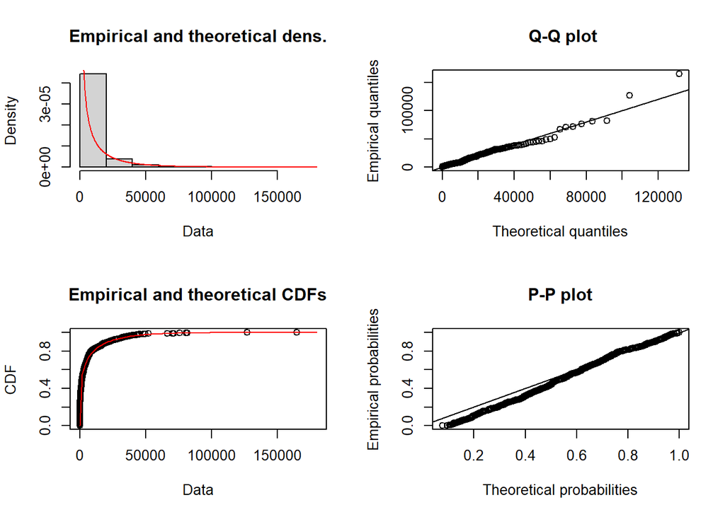

```r
a=fitdist(data1$kgs, distr = "gamma",start=list(shape = 1, rate = 2), lower = -1,method = "mme")
plot(a)
```

```r
ks.test(na.omit(data1$kgs), "pgamma", a$estimate[1],a$estimate[2])
```

```
##
##  One-sample Kolmogorov-Smirnov test
##
## data:  na.omit(data1$kgs)
## D = 0.11025, p-value = 8.39e-07
## alternative hypothesis: two-sided
```

```r
gamma_test(data1$kgs)
```

```
##
##  Test of fit for the Gamma distribution
##
## data:  data1$kgs
## V = 5.3594, p-value = 0.0001509
```

### 3.6.3 Regression model

```r
ind=which(data1$euros==0)
if(length(ind)>0){
data1=data1[-ind,]}
x=as.factor(data1$Covid)
table(x)
```

```
## x
## After state of alarm                  No      State of alarm 1
##                   91                  308                   68
##     State of alarm 2
##                  137
```

```r
y=as.numeric(data1$euros)
x=relevel(x, ref = "No ")
z=data1$kgs


Model<-glm((y)~x,family=Gamma(link=log))
cooksd <- cooks.distance(Model)
influential <- cooksd[(cooksd > (3 * mean(cooksd, na.rm = TRUE)))]
influential=as.numeric(names(influential))
y=y[-influential]
xaux=x[-influential]
Model<-glm((y)~xaux,family=Gamma(link=log))
summary(Model)
```

```
##
## Call:
## glm(formula = (y) ~ xaux, family = Gamma(link = log))
##
## Deviance Residuals:
##     Min       1Q   Median       3Q      Max
## -2.7825  -0.4500  -0.1626   0.2387   1.1986
##
## Coefficients:
##                          Estimate Std. Error t value Pr(>|t|)
## (Intercept)              -0.51842    0.02926 -17.719  < 2e-16 ***
## xauxAfter state of alarm -0.33509    0.06183  -5.420 8.84e-08 ***
## xauxState of alarm 1      0.04898    0.07197   0.681    0.496
## xauxState of alarm 2      0.21476    0.05382   3.990 7.47e-05 ***
## ---
## Signif. codes:  0 '***' 0.001 '**' 0.01 '*' 0.05 '.' 0.1 ' ' 1
##
## (Dispersion parameter for Gamma family taken to be 0.2551018)
##
##     Null deviance: 155.90  on 567  degrees of freedom
## Residual deviance: 141.02  on 564  degrees of freedom
## AIC: 125.9
##
## Number of Fisher Scoring iterations: 5
```

```r
Model.aux<-glm((z)~x,family=Gamma(link=log))

cooksd <- cooks.distance(Model.aux)
influential <- cooksd[(cooksd > (3 * mean(cooksd, na.rm = TRUE)))]
influential=as.numeric(names(influential))
z=z[-influential]
xaux=x[-influential]
Model.aux<-glm((z)~xaux,family=Gamma(link=log))
summary(Model.aux)
```

```
##
## Call:
## glm(formula = (z) ~ xaux, family = Gamma(link = log))
##
## Deviance Residuals:
##     Min       1Q   Median       3Q      Max
## -3.8412  -1.9526  -0.8761   0.1302   2.9081
##
## Coefficients:
##                          Estimate Std. Error t value Pr(>|t|)
## (Intercept)               8.81525    0.08644 101.977  < 2e-16 ***
## xauxAfter state of alarm  0.19573    0.18338   1.067    0.286
## xauxState of alarm 1     -2.80303    0.20779 -13.490  < 2e-16 ***
## xauxState of alarm 2     -0.78710    0.15782  -4.987 8.12e-07 ***
## ---
## Signif. codes:  0 '***' 0.001 '**' 0.01 '*' 0.05 '.' 0.1 ' ' 1
##
## (Dispersion parameter for Gamma family taken to be 2.249235)
##
##     Null deviance: 1985.5  on 578  degrees of freedom
## Residual deviance: 1709.0  on 575  degrees of freedom
## AIC: 10504
##
## Number of Fisher Scoring iterations: 9
```

## 3.7 Micromesistius poutassou

```r
data1=subset(data_M,data_M$specie=="WHB-BACALADILLA")
```

### 3.7.1 Exploratory analysis

#### 3.7.1.1 Price by covid category (boxplot)

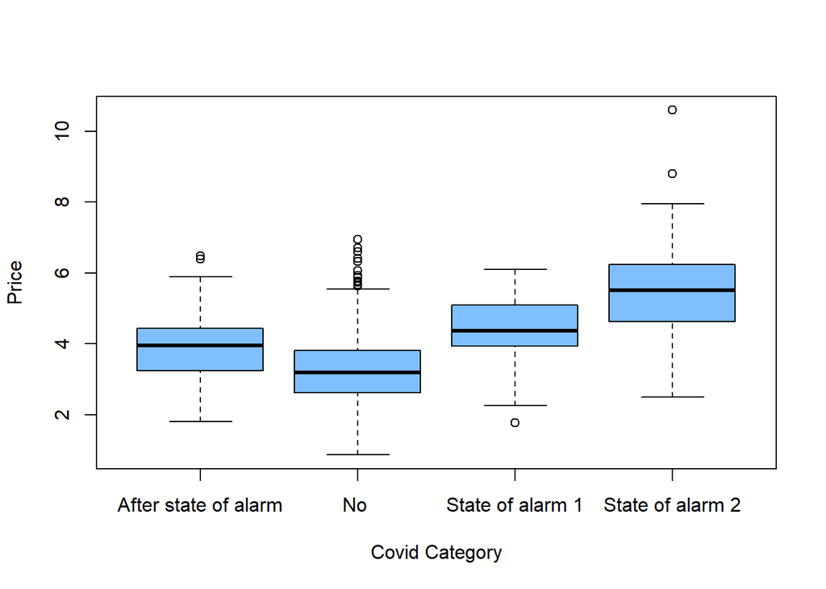

```r
boxplot(data1$euros~data1$Covid, col = rgb(0, 0.5, 1, alpha = 0.5),xlab="Covid Category",ylab="Price")
```

### 3.7.2 Abundance by covid category (boxplot)

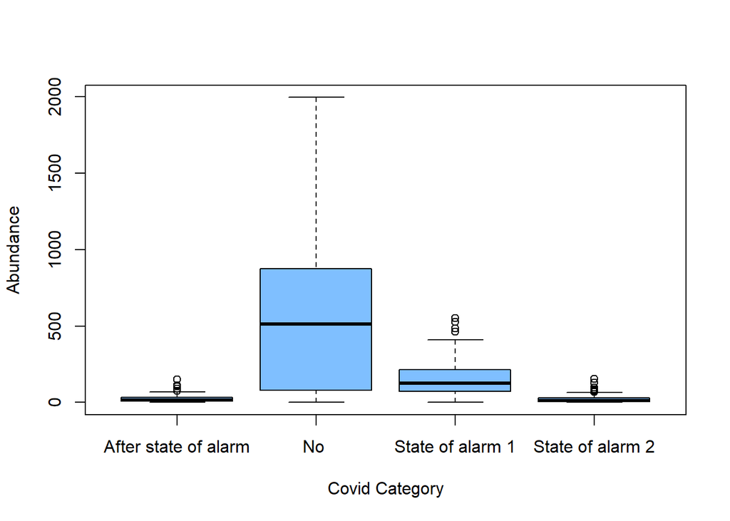

```r
boxplot(data1$kgs~data1$Covid, col = rgb(0, 0.5, 1, alpha = 0.5),xlab="Covid Category",ylab="Abundance")
```

#### 3.7.2.1 Price vs Abundance (scatter plot)

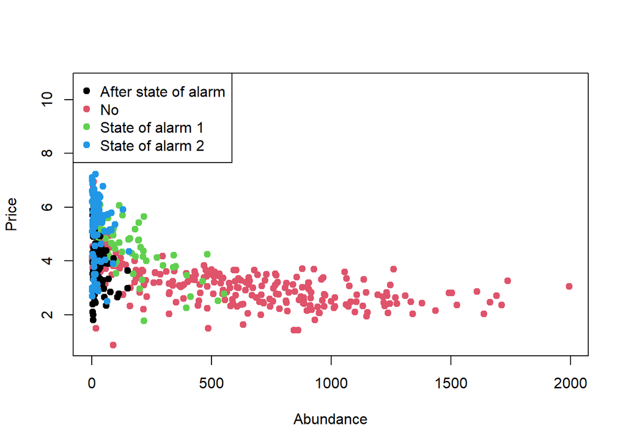

```r
plot(data1$kgs,data1$euros,
     pch = 19,
     col = factor(data1$Covid),xlab="Abundance",ylab = "Price")

# Legend
legend("topleft",
       legend = levels(factor(data1$Covid)),
       pch = 19,
       col = factor(levels(factor(data1$Covid))))
```

```r
cor.test(data1$kgs,data1$euros)
```

```
##
##  Pearson's product-moment correlation
##
## data:  data1$kgs and data1$euros
## t = -17.246, df = 515, p-value < 2.2e-16
## alternative hypothesis: true correlation is not equal to 0
## 95 percent confidence interval:
##  -0.6570022 -0.5473711
## sample estimates:
##        cor
## -0.6050467
```

Is gamma a correct distribution for the response variable PRICE?

```r
summary(data1$euros)
```

```
##    Min. 1st Qu.  Median    Mean 3rd Qu.    Max.
##  0.8693  2.8974  3.6591  3.9245  4.9498 10.5919
```

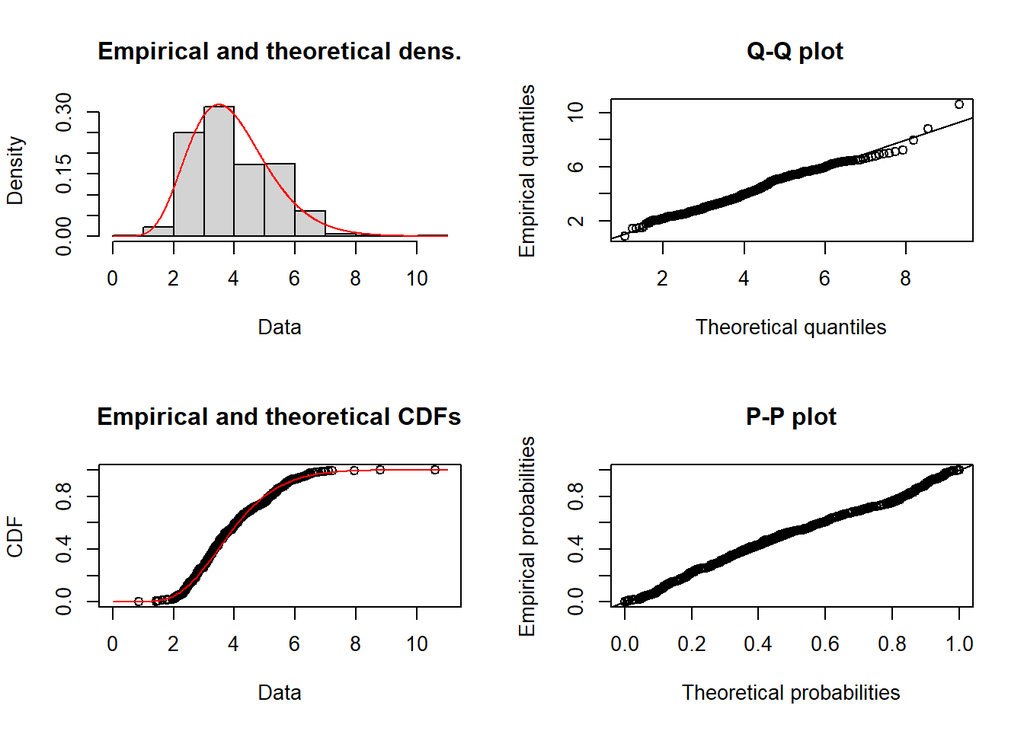

```r
a=fitdist(data1$euros, distr = "gamma",start=list(shape = 1, rate = 2), lower = -1,method = "mme")
plot(a)
```

```r
ks.test(na.omit(data1$euros), "pgamma", a$estimate[1],a$estimate[2])
```

```
##
##  One-sample Kolmogorov-Smirnov test
##
## data:  na.omit(data1$euros)
## D = 0.049891, p-value = 0.1524
## alternative hypothesis: two-sided
```

```r
gamma_test(data1$euros)
```

```
##
##  Test of fit for the Gamma distribution
##
## data:  data1$euros
## V = 1.0375, p-value = 0.4632
```

Is gamma a correct distribution for the response variable ABUNDANCE?

```r
summary(data1$kgs)
```

```
##    Min. 1st Qu.  Median    Mean 3rd Qu.    Max.
##    0.78   17.39   88.13  325.69  576.68 1994.91
```

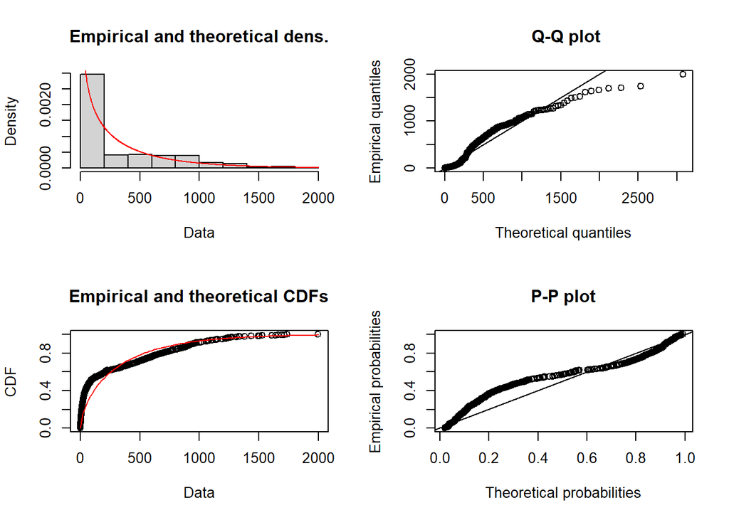

```r
a=fitdist(data1$kgs, distr = "gamma",start=list(shape = 1, rate = 2), lower = -1,method = "mme")
plot(a)
```

```r
ks.test(na.omit(data1$kgs), "pgamma", a$estimate[1],a$estimate[2])
```

```
##
##  One-sample Kolmogorov-Smirnov test
##
## data:  na.omit(data1$kgs)
## D = 0.17407, p-value = 4.952e-14
## alternative hypothesis: two-sided
```

```r
gamma_test(data1$kgs)
```

```
##
##  Test of fit for the Gamma distribution
##
## data:  data1$kgs
## V = -3.503, p-value = 0.01325
```

### 3.7.3 Regression model

```r
x=as.factor(data1$Covid)
table(x)
```

```
## x
## After state of alarm                  No      State of alarm 1
##                   88                  284                   59
##     State of alarm 2
##                   86
```

```r
y=as.numeric(data1$euros)
x=relevel(x, ref = "No ")
z=data1$kgs


Model<-glm((y)~x,family=Gamma(link=log))
cooksd <- cooks.distance(Model)
influential <- cooksd[(cooksd > (3 * mean(cooksd, na.rm = TRUE)))]
influential=as.numeric(names(influential))
y=y[-influential]
xaux=x[-influential]
Model<-glm((y)~xaux,family=Gamma(link=log))
summary(Model)
```

```
##
## Call:
## glm(formula = (y) ~ xaux, family = Gamma(link = log))
##
## Deviance Residuals:
##      Min        1Q    Median        3Q       Max
## -0.73215  -0.17481  -0.01977   0.12108   0.59961
##
## Coefficients:
##                          Estimate Std. Error t value Pr(>|t|)
## (Intercept)               1.18928    0.01459  81.491  < 2e-16 ***
## xauxAfter state of alarm  0.17035    0.03123   5.455 7.96e-08 ***
## xauxState of alarm 1      0.31864    0.03704   8.604  < 2e-16 ***
## xauxState of alarm 2      0.51995    0.03156  16.477  < 2e-16 ***
## ---
## Signif. codes:  0 '***' 0.001 '**' 0.01 '*' 0.05 '.' 0.1 ' ' 1
##
## (Dispersion parameter for Gamma family taken to be 0.05793223)
##
##     Null deviance: 45.425  on 471  degrees of freedom
## Residual deviance: 26.637  on 468  degrees of freedom
## AIC: 1227.8
##
## Number of Fisher Scoring iterations: 4
```

```r
Model.aux<-glm((z)~x,family=Gamma(link=log))

cooksd <- cooks.distance(Model.aux)
influential <- cooksd[(cooksd > (3 * mean(cooksd, na.rm = TRUE)))]
influential=as.numeric(names(influential))
z=z[-influential]
xaux=x[-influential]
Model.aux<-glm((z)~xaux,family=Gamma(link=log))
summary(Model.aux)
```

```
##
## Call:
## glm(formula = (z) ~ xaux, family = Gamma(link = log))
##
## Deviance Residuals:
##     Min       1Q   Median       3Q      Max
## -3.2773  -1.0915  -0.1578   0.4759   1.7543
##
## Coefficients:
##                          Estimate Std. Error t value Pr(>|t|)
## (Intercept)               6.28511    0.04898  128.33   <2e-16 ***
## xauxAfter state of alarm -3.33314    0.10432  -31.95   <2e-16 ***
## xauxState of alarm 1     -1.39087    0.12431  -11.19   <2e-16 ***
## xauxState of alarm 2     -3.62602    0.10700  -33.89   <2e-16 ***
## ---
## Signif. codes:  0 '***' 0.001 '**' 0.01 '*' 0.05 '.' 0.1 ' ' 1
##
## (Dispersion parameter for Gamma family taken to be 0.6787951)
##
##     Null deviance: 1350.31  on 489  degrees of freedom
## Residual deviance:  606.68  on 486  degrees of freedom
## AIC: 5933.3
##
## Number of Fisher Scoring iterations: 6
```

## 3.8 Argyrosomus regius

```r
data1=subset(data_M,data_M$specie=="MGR-CORVINA")
```

### 3.8.1 Exploratory analysis

#### 3.8.1.1 Price by covid category (boxplot)

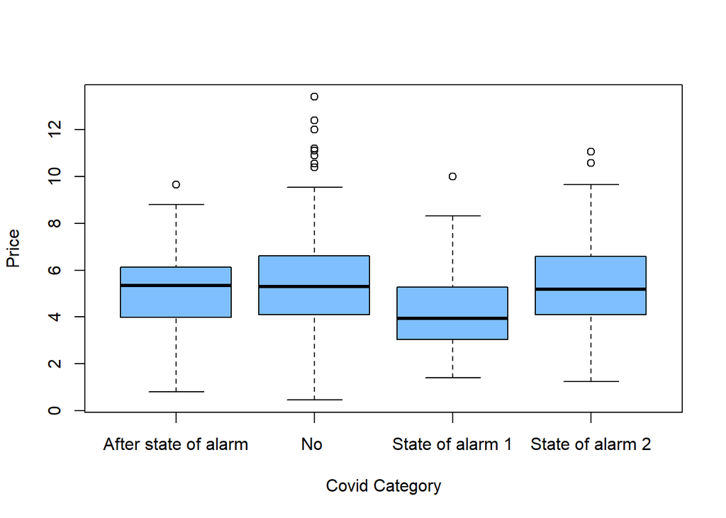

```r
boxplot(data1$euros~data1$Covid, col = rgb(0, 0.5, 1, alpha = 0.5),xlab="Covid Category",ylab="Price")
```

### 3.8.2 Abundance by covid category (boxplot)

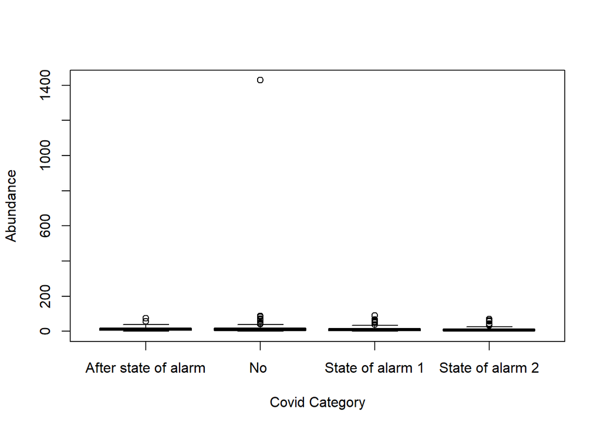

```r
boxplot(data1$kgs~data1$Covid, col = rgb(0, 0.5, 1, alpha = 0.5),xlab="Covid Category",ylab="Abundance")
```

#### 3.8.2.1 Price vs Abundance (scatter plot)

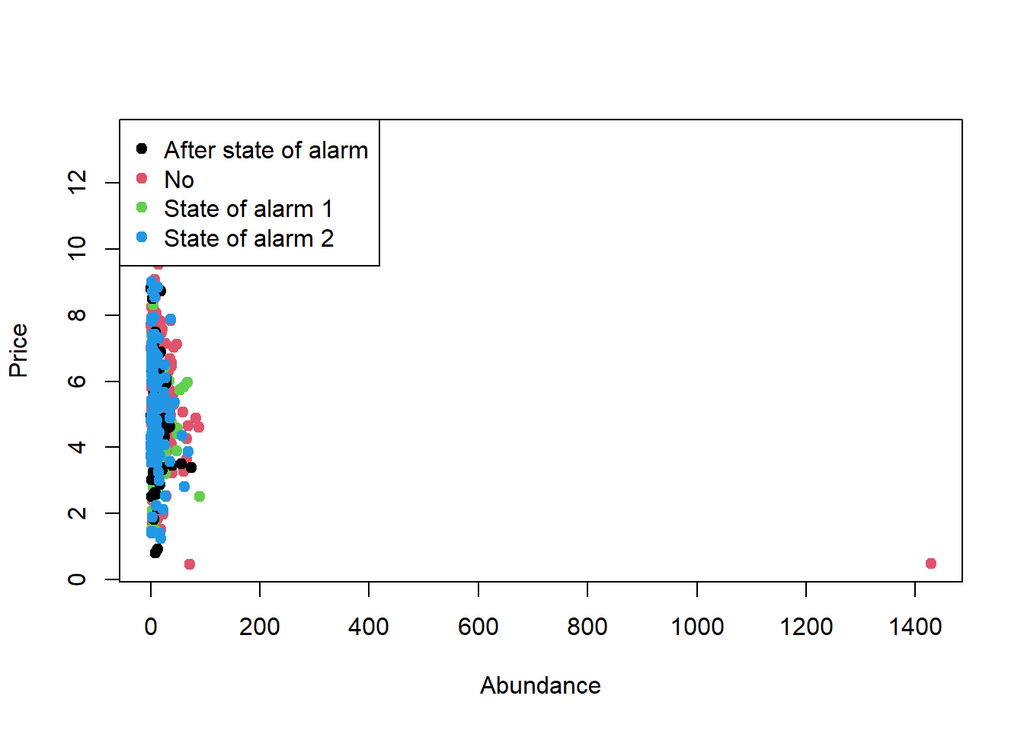

```r
plot(data1$kgs,data1$euros,
     pch = 19,
     col = factor(data1$Covid),xlab="Abundance",ylab = "Price")

# Legend
legend("topleft",
       legend = levels(factor(data1$Covid)),
       pch = 19,
       col = factor(levels(factor(data1$Covid))))
```

```r
cor.test(data1$kgs,data1$euros)
```

```
##
##  Pearson's product-moment correlation
##
## data:  data1$kgs and data1$euros
## t = -3.2577, df = 505, p-value = 0.001199
## alternative hypothesis: true correlation is not equal to 0
## 95 percent confidence interval:
##  -0.22770236 -0.05709521
## sample estimates:
##        cor
## -0.1434645
```

Is gamma a correct distribution for the response variable PRICE?

```r
summary(data1$euros)
```

```
##    Min. 1st Qu.  Median    Mean 3rd Qu.    Max.
##  0.4565  3.9445  5.1192  5.2476  6.4094 13.4000
```

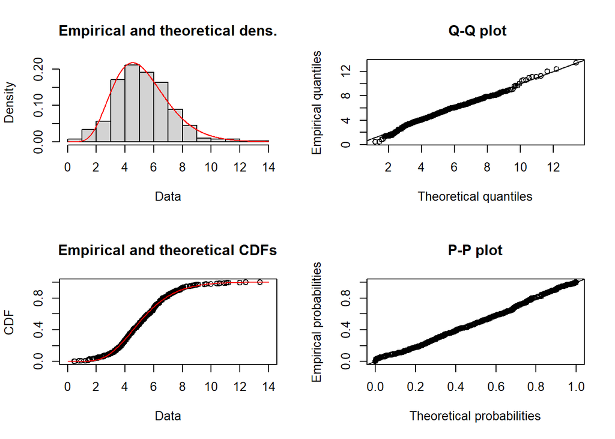

```r
a=fitdist(data1$euros, distr = "gamma",start=list(shape = 1, rate = 2), lower = -1,method = "mme")
plot(a)
```

```r
ks.test(na.omit(data1$euros), "pgamma", a$estimate[1],a$estimate[2])
```

```
##
##  One-sample Kolmogorov-Smirnov test
##
## data:  na.omit(data1$euros)
## D = 0.033305, p-value = 0.6273
## alternative hypothesis: two-sided
```

```r
gamma_test(data1$euros)
```

```
##
##  Test of fit for the Gamma distribution
##
## data:  data1$euros
## V = -4.8489, p-value = 0.0006066
```

Is gamma a correct distribution for the response variable ABUNDANCE?

```r
summary(data1$kgs)
```

```
##    Min. 1st Qu.  Median    Mean 3rd Qu.    Max.
##    0.50    4.40    9.16   16.70   17.92 1428.52
```

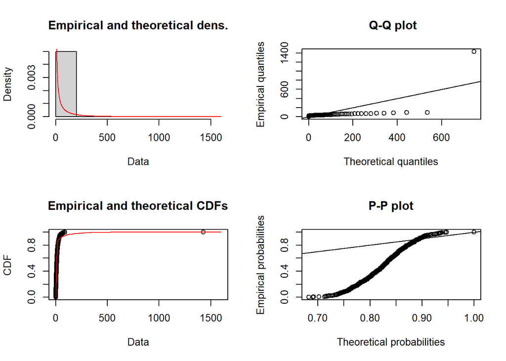

```r
a=fitdist(data1$kgs, distr = "gamma",start=list(shape = 1, rate = 2), lower = -1,method = "mme")
plot(a)
```

```r
ks.test(na.omit(data1$kgs), "pgamma", a$estimate[1],a$estimate[2])
```

```
##
##  One-sample Kolmogorov-Smirnov test
##
## data:  na.omit(data1$kgs)
## D = 0.70487, p-value < 2.2e-16
## alternative hypothesis: two-sided
```

```r
gamma_test(data1$kgs)
```

```
##
##  Test of fit for the Gamma distribution
##
## data:  data1$kgs
## V = 150.64, p-value < 2.2e-16
```

### 3.8.3 Regression model

```r
x=as.factor(data1$Covid)
table(x)
```

```
## x
## After state of alarm                  No      State of alarm 1
##                   75                  262                   62
##     State of alarm 2
##                  108
```

```r
y=as.numeric(data1$euros)
x=relevel(x, ref = "No ")
z=data1$kgs


Model<-glm((y)~x,family=Gamma(link=log))
cooksd <- cooks.distance(Model)
influential <- cooksd[(cooksd > (3 * mean(cooksd, na.rm = TRUE)))]
influential=as.numeric(names(influential))
y=y[-influential]
xaux=x[-influential]
Model<-glm((y)~xaux,family=Gamma(link=log))
summary(Model)
```

```
##
## Call:
## glm(formula = (y) ~ xaux, family = Gamma(link = log))
##
## Deviance Residuals:
##      Min        1Q    Median        3Q       Max
## -1.75605  -0.23339  -0.02062   0.19269   0.75397
##
## Coefficients:
##                           Estimate Std. Error t value Pr(>|t|)
## (Intercept)               1.671810   0.018406  90.832  < 2e-16 ***
## xauxAfter state of alarm -0.030847   0.041352  -0.746    0.456
## xauxState of alarm 1     -0.275288   0.046656  -5.900 7.08e-09 ***
## xauxState of alarm 2     -0.002422   0.035328  -0.069    0.945
## ---
## Signif. codes:  0 '***' 0.001 '**' 0.01 '*' 0.05 '.' 0.1 ' ' 1
##
## (Dispersion parameter for Gamma family taken to be 0.08638475)
##
##     Null deviance: 50.347  on 459  degrees of freedom
## Residual deviance: 47.432  on 456  degrees of freedom
## AIC: 1738.7
##
## Number of Fisher Scoring iterations: 4
```

```r
Model.aux<-glm((z)~x,family=Gamma(link=log))

cooksd <- cooks.distance(Model.aux)
influential <- cooksd[(cooksd > (3 * mean(cooksd, na.rm = TRUE)))]
influential=as.numeric(names(influential))
z=z[-influential]
xaux=x[-influential]
Model.aux<-glm((z)~xaux,family=Gamma(link=log))
summary(Model.aux)
```

```
##
## Call:
## glm(formula = (z) ~ xaux, family = Gamma(link = log))
##
## Deviance Residuals:
##     Min       1Q   Median       3Q      Max
## -2.1892  -0.9219  -0.3640   0.3330   2.5700
##
## Coefficients:
##                            Estimate Std. Error t value Pr(>|t|)
## (Intercept)               2.6685178  0.0599262  44.530  < 2e-16 ***
## xauxAfter state of alarm -0.0972785  0.1275038  -0.763 0.445858
## xauxState of alarm 1      0.0007338  0.1386097   0.005 0.995778
## xauxState of alarm 2     -0.3933920  0.1118826  -3.516 0.000478 ***
## ---
## Signif. codes:  0 '***' 0.001 '**' 0.01 '*' 0.05 '.' 0.1 ' ' 1
##
## (Dispersion parameter for Gamma family taken to be 0.9372898)
##
##     Null deviance: 436.30  on 499  degrees of freedom
## Residual deviance: 424.86  on 496  degrees of freedom
## AIC: 3563.6
##
## Number of Fisher Scoring iterations: 5
```

## 3.9 Pagellus bogaraveo

```r
data1=subset(data_M,data_M$specie=="SBR-BESUGO DE LA PINTA O VORAZ")
```

### 3.9.1 Exploratory analysis

#### 3.9.1.1 Price by covid category (boxplot)

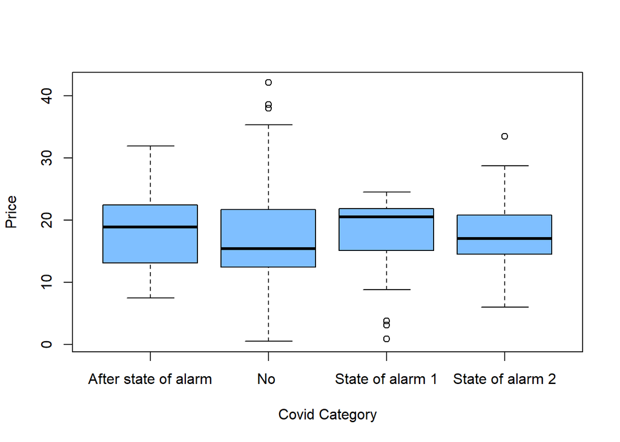

```r
boxplot(data1$euros~data1$Covid, col = rgb(0, 0.5, 1, alpha = 0.5),xlab="Covid Category",ylab="Price")
```

### 3.9.2 Abundance by covid category (boxplot)

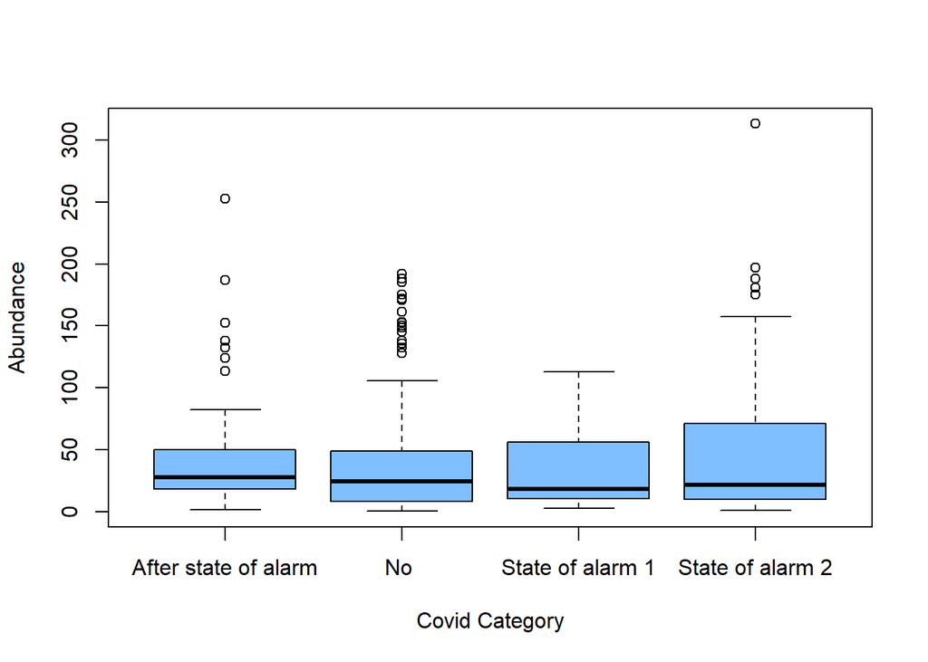

```r
boxplot(data1$kgs~data1$Covid, col = rgb(0, 0.5, 1, alpha = 0.5),xlab="Covid Category",ylab="Abundance")
```

#### 3.9.2.1 Price vs Abundance (scatter plot)

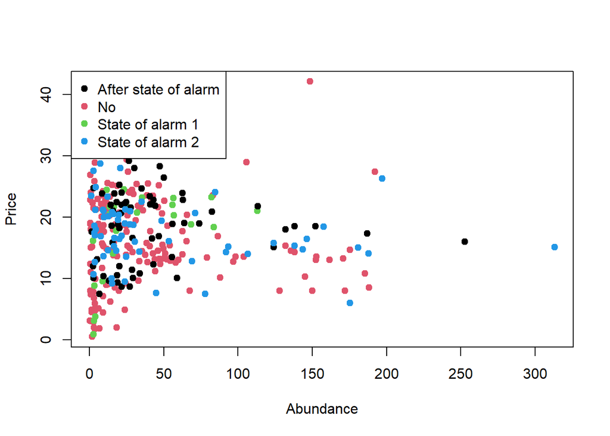

```r
plot(data1$kgs,data1$euros,
     pch = 19,
     col = factor(data1$Covid),xlab="Abundance",ylab = "Price")

# Legend
legend("topleft",
       legend = levels(factor(data1$Covid)),
       pch = 19,
       col = factor(levels(factor(data1$Covid))))
```

```r
cor.test(data1$kgs,data1$euros)
```

```
##
##  Pearson's product-moment correlation
##
## data:  data1$kgs and data1$euros
## t = -0.053547, df = 316, p-value = 0.9573
## alternative hypothesis: true correlation is not equal to 0
## 95 percent confidence interval:
##  -0.1129595  0.1070080
## sample estimates:
##          cor
## -0.003012224
```

Is gamma a correct distribution for the response variable PRICE?

```r
summary(data1$euros)
```

```
##    Min. 1st Qu.  Median    Mean 3rd Qu.    Max.
##    0.50   13.06   17.60   17.15   21.81   42.11
```

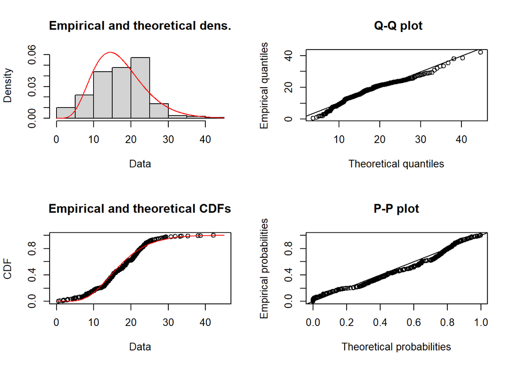

```r
a=fitdist(data1$euros, distr = "gamma",start=list(shape = 1, rate = 2), lower = -1,method = "mme")
plot(a)
```

```r
ks.test(na.omit(data1$euros), "pgamma", a$estimate[1],a$estimate[2])
```

```
##
##  One-sample Kolmogorov-Smirnov test
##
## data:  na.omit(data1$euros)
## D = 0.083117, p-value = 0.02471
## alternative hypothesis: two-sided
```

```r
gamma_test(data1$euros)
```

```
##
##  Test of fit for the Gamma distribution
##
## data:  data1$euros
## V = -8.5677, p-value = 1.376e-09
```

Is gamma a correct distribution for the response variable ABUNDANCE?

```r
summary(data1$kgs)
```

```
##    Min. 1st Qu.  Median    Mean 3rd Qu.    Max.
##   0.300   9.463  23.945  41.428  50.400 313.100
```

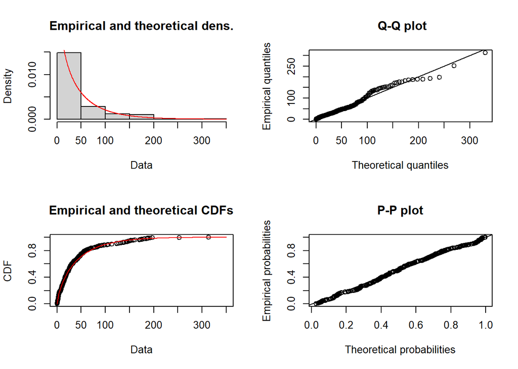

```r
a=fitdist(data1$kgs, distr = "gamma",start=list(shape = 1, rate = 2), lower = -1,method = "mme")
plot(a)
```

```r
ks.test(na.omit(data1$kgs), "pgamma", a$estimate[1],a$estimate[2])
```

```
##
##  One-sample Kolmogorov-Smirnov test
##
## data:  na.omit(data1$kgs)
## D = 0.053741, p-value = 0.3174
## alternative hypothesis: two-sided
```

```r
gamma_test(data1$kgs)
```

```
##
##  Test of fit for the Gamma distribution
##
## data:  data1$kgs
## V = 1.642, p-value = 0.2456
```

### 3.9.3 Regression model

```r
x=as.factor(data1$Covid)
table(x)
```

```
## x
## After state of alarm                  No      State of alarm 1
##                   62                  171                   23
##     State of alarm 2
##                   62
```

```r
y=as.numeric(data1$euros)
x=relevel(x, ref = "No ")
z=data1$kgs


Model<-glm((y)~x,family=Gamma(link=log))
cooksd <- cooks.distance(Model)
influential <- cooksd[(cooksd > (3 * mean(cooksd, na.rm = TRUE)))]
influential=as.numeric(names(influential))
y=y[-influential]
xaux=x[-influential]
Model<-glm((y)~xaux,family=Gamma(link=log))
summary(Model)
```

```
##
## Call:
## glm(formula = (y) ~ xaux, family = Gamma(link = log))
##
## Deviance Residuals:
##      Min        1Q    Median        3Q       Max
## -2.23020  -0.20263  -0.00894   0.21743   0.74821
##
## Coefficients:
##                          Estimate Std. Error t value Pr(>|t|)
## (Intercept)               2.76217    0.02832  97.543   <2e-16 ***
## xauxAfter state of alarm  0.14009    0.05530   2.533   0.0118 *
## xauxState of alarm 1      0.24617    0.09551   2.578   0.0104 *
## xauxState of alarm 2      0.08514    0.05565   1.530   0.1271
## ---
## Signif. codes:  0 '***' 0.001 '**' 0.01 '*' 0.05 '.' 0.1 ' ' 1
##
## (Dispersion parameter for Gamma family taken to be 0.1331105)
##
##     Null deviance: 59.019  on 298  degrees of freedom
## Residual deviance: 57.417  on 295  degrees of freedom
## AIC: 2003.3
##
## Number of Fisher Scoring iterations: 4
```

```r
Model.aux<-glm((z)~x,family=Gamma(link=log))

cooksd <- cooks.distance(Model.aux)
influential <- cooksd[(cooksd > (3 * mean(cooksd, na.rm = TRUE)))]
influential=as.numeric(names(influential))
z=z[-influential]
xaux=x[-influential]
Model.aux<-glm((z)~xaux,family=Gamma(link=log))
summary(Model.aux)
```

```
##
## Call:
## glm(formula = (z) ~ xaux, family = Gamma(link = log))
##
## Deviance Residuals:
##     Min       1Q   Median       3Q      Max
## -2.6923  -1.0064  -0.3419   0.3656   2.1516
##
## Coefficients:
##                          Estimate Std. Error t value Pr(>|t|)
## (Intercept)               3.41028    0.07804  43.700   <2e-16 ***
## xauxAfter state of alarm  0.01566    0.15362   0.102    0.919
## xauxState of alarm 1     -0.35851    0.24020  -1.493    0.137
## xauxState of alarm 2     -0.06604    0.15681  -0.421    0.674
## ---
## Signif. codes:  0 '***' 0.001 '**' 0.01 '*' 0.05 '.' 0.1 ' ' 1
##
## (Dispersion parameter for Gamma family taken to be 0.9805055)
##
##     Null deviance: 338.08  on 288  degrees of freedom
## Residual deviance: 335.90  on 285  degrees of freedom
## AIC: 2544
##
## Number of Fisher Scoring iterations: 6
```

## 3.10 Scomber japonicus

```r
data1=subset(data_M,data_M$specie=="MAS-CABALLA DEL SUR O TONINO")
head(data1)
```

```
##      Covid       date                       specie     euros    kgs
## 2234   No  01/04/2019 MAS-CABALLA DEL SUR O TONINO 1.6198675   7.55
## 2257   No  02/04/2019 MAS-CABALLA DEL SUR O TONINO 0.4700575 333.64
## 2278   No  03/04/2019 MAS-CABALLA DEL SUR O TONINO 0.3053823 415.25
## 2299   No  04/04/2019 MAS-CABALLA DEL SUR O TONINO 0.2705244 692.47
## 2336   No  08/04/2019 MAS-CABALLA DEL SUR O TONINO 0.7666667  60.00
## 2356   No  09/04/2019 MAS-CABALLA DEL SUR O TONINO 0.6295842 252.50
```